# Comparing seasonal and latitudinal patterns in thermal adaptation

- Show All Code
- Hide All Code
- View Source

Published

2026-10-31

## Main Message

By assaying thermal limits several times per year in natural populations distributed across a large latitudinal gradient, we highlight the importance of intra-specific variation for predicting vulnerability to climate change. Indeed, across the entire spatiotemporal framework examined here, we observed an ~12°C range in thermal limits. Both spatial and temporal variations in thermal limits are essential for robust predictions. Also highlighted in this study are the major differences in thermal limits between the various cryptic lineages of *Acartia tonsa*. The broad (and sometimes overlapping) distrbutions of these clades provide a unique opportunity to compare replicate spatiotemporal patterns in adaptation against a relatively similar genetic background.

## 1. Collections and environment

Collection sites, conditions at the time of collection, continuous temperature records, and the timing of collections relative to copepod generation times.

### Sites and collection conditions

Copepods were collected by surface tow from sites across the Western Atlantic at several times throughout the year. The sites are shown below along with surface temperatures and salinity were measured at the time of collection. Across the entire set of collections, temperature ranged from 10°C to 36°C.

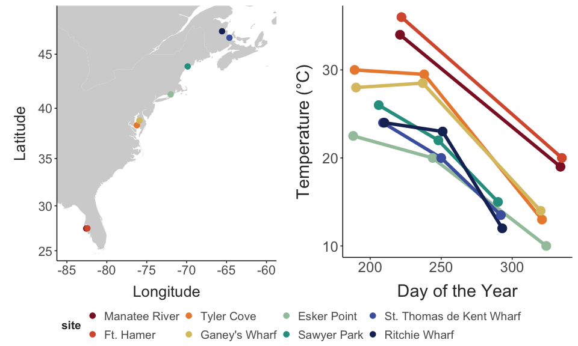

```r
coords = site_data %>%
  dplyr::select(site, long, lat) %>%
  distinct() %>%
  filter(site != "Key Largo")

site_map = map_data("world") %>%
  filter(region %in% c("USA", "Canada")) %>%
  ggplot() +
  geom_polygon(aes(x = long, y = lat, group = group),
               fill = "lightgrey") +
  coord_map(xlim = c(-85,-60),
            ylim = c(25, 48)) +
  geom_point(data = coords,
             mapping = aes(x = long, y = lat, colour = site),
             size = 3) +
  scale_colour_manual(values = site_cols) +
  labs(x = "Longitude",
       y = "Latitude") +
  theme_matt(base_size = 16)

site_temp_plot = ggplot(site_temps, aes(x = doy, y = collection_temp, colour = site)) +
  geom_line(linewidth = 2) +
  geom_point(size = 5) +
  scale_colour_manual(values = site_cols) +
  labs(y = "Temperature (°C)",
       x = "Day of the Year") +
  theme_matt() +
  theme(legend.position = "right")

ggarrange(site_map, site_temp_plot, common.legend = T, legend = "bottom")
```

Collections aimed to obtain copepods near the onset of peak temperatures, after peak temperatures, and then after temperatures cooled during the Fall. To put the collections into this larger seasonal context, we examined continuous temperature records for each site. Continuous data is not available for all sites, however, so here we’ve pieced together daily temperature values from either local temperature sensors (sites in Florida and the Chesapeake) and high resolution satellite temperature data (Connecticut, Maine, and the Canadian sites). This satellite data comes from the NOAA 1/4° Daily Optimum Interpolation Sea Surface Temperature (OISST).

These temperature profiles are shown below, with the temperatures measured during the time of collection included for comparison While collection temperatures in Maine did not always match the recorded daily averages, across all sites the temperature records do give a general sense of the timing of seasonal maxima (and the proximity of collections to the seasonal maximum temperature). In general, the first sample from each site fell just after the site reached the warmest period. The exception to that pattern is in Florida, where collections occurred after an extended period of high temperatures.

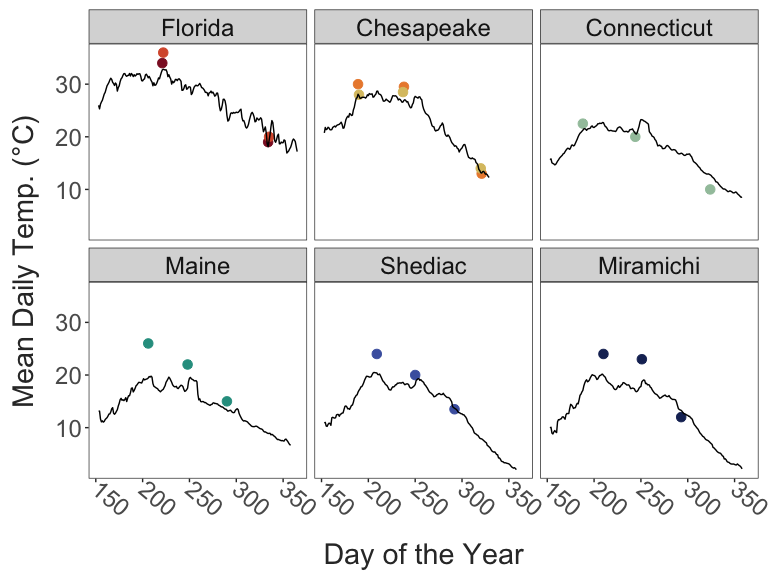

```r
temp_profiles = temp_profiles %>%
  filter(doy > 100) %>%
  mutate(region = fct_relevel(region, "Florida", "Chesapeake", "Connecticut",
                              "Maine", "Shediac", "Miramichi"))

site_temps2 = site_temps %>%
  mutate(region = case_when(
    site == "Manatee River" ~ "Florida",
    site == "Ft. Hamer" ~ "Florida",
    site == "Tyler Cove" ~ "Chesapeake",
    site == "Ganey's Wharf" ~ "Chesapeake",
    site == "Esker Point" ~ "Connecticut",
    site == "Sawyer Park" ~ "Maine",
    site == "St. Thomas de Kent Wharf" ~ "Shediac",
    site == "Ritchie Wharf" ~ "Miramichi"),
    region = fct_relevel(region, "Florida", "Chesapeake", "Connecticut",
                         "Maine", "Shediac", "Miramichi"))

ggplot(temp_profiles, aes(x = doy, y = temp_c)) +
  facet_wrap(region~.) +
  geom_point(data = site_temps2,
             aes(x = doy, y = collection_temp, colour = site),
             size = 3) +
  geom_line() +
  scale_colour_manual(values = site_cols) +
  labs(x = "Day of the Year",
       y = "Mean Daily Temp. (°C)") +
  theme_matt_facets() +
  theme(legend.position = "none",
        axis.text.x = element_text(angle = 320, hjust = 0, vjust = 0.5))
```

Exact locations for the sites are provided here:

```r
site_data %>%
  arrange(lat) %>%
  select("Site" = site, "Region" = region, "Lat" = lat, "Long" = long) %>%
  knitr::kable(align = "c")
```

| Site | Region | Lat | Long |
| --- | --- | --- | --- |
| Key Largo | Florida | 25.28391 | -80.33014 |
| Manatee River | Florida | 27.50561 | -82.57277 |
| Ft. Hamer | Florida | 27.52488 | -82.43101 |
| Tyler Cove | Maryland | 38.35083 | -76.22902 |
| Ganey’s Wharf | Maryland | 38.80555 | -75.90906 |
| Esker Point | Connecticut | 41.32081 | -72.00166 |
| Sawyer Park | Maine | 43.90698 | -69.87179 |
| St. Thomas de Kent Wharf | New Brunswick | 46.44761 | -64.63692 |
| Ritchie Wharf | New Brunswick | 47.00481 | -65.56291 |

The latitudinal gradient covers a wide range of seasonality. Shown below is the temperature range. While based on collection temperatures, and therefore an underestimate of the total seasonal range of temperatures, these patterns are representative of the expected latitudinal gradient in seasonality.

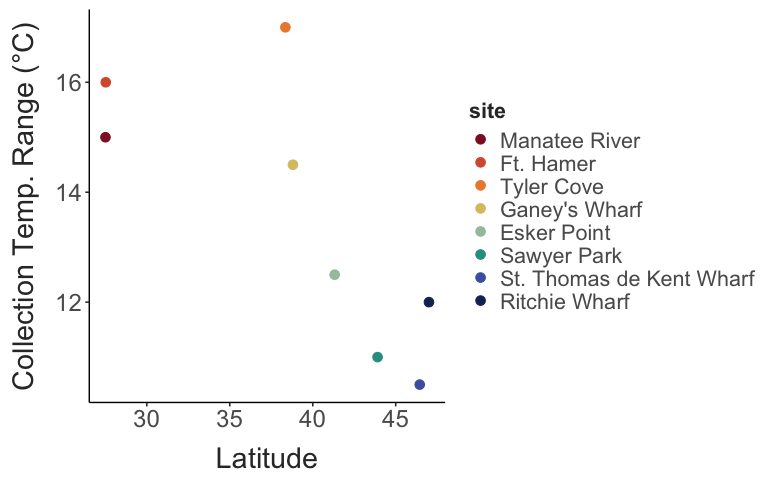

```r
site_temps %>%
  group_by(site, lat) %>%
  summarise(temp_range = max(collection_temp) - min(collection_temp)) %>%
  ggplot(aes(x = lat, y = temp_range)) +
  geom_point(aes(colour = site),
             size = 3) +
  scale_color_manual(values = site_cols) +
  labs(x = "Latitude",
       y = "Collection Temp. Range (°C)") +
  theme_matt() +
  theme(legend.position = "right")
```

There was a general increase in the collection temperature range at warmer sites. This provides an opportunity to disentangle some of the traditionally proposed hypotheses about thermal adaptation (macrophysiological gradients often include stable and warm environments contrasted with cooler, more variable environment).

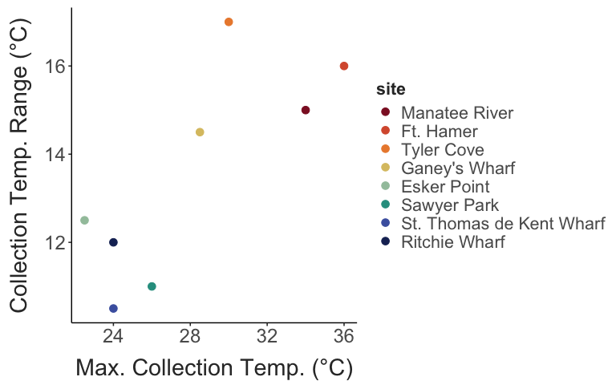

```r
site_temps %>%
  group_by(site, lat) %>%
  summarise(
    max_temp = max(collection_temp),
    temp_range = max(collection_temp) - min(collection_temp)) %>%
  ggplot(aes(x = max_temp, y = temp_range)) +
  geom_point(aes(colour = site),
             size = 3) +
  scale_color_manual(values = site_cols) +
  labs(x = "Max. Collection Temp. (°C)",
       y = "Collection Temp. Range (°C)") +
  theme_matt() +
  theme(legend.position = "right")
```

### Long-term site temperatures (MUR SST)

Daily sea-surface temperature for 2014–2023 was taken from the MUR SST analysis (GHRSST Level 4, ~1 km) for each site, averaging the water pixels within 5 km of the site (`Scripts/05_site_environment.R`). Where MUR has no water near a site (Ganey’s Wharf, Ritchie Wharf), the water within 5 km of the nearest water pixel (14–19 km away) was used. MUR agreed closely with nearby monitoring stations wherever it resolves the site’s own water (mean bias −0.4 to +0.4 °C at Noank, New London, Gooses Reef, Port Manatee, Portland and the Manatee River gauge). At Ganey’s Wharf, Chesapeake Bay Program station ET5.1 (at the wharf) is 2–4 °C warmer than MUR in spring and 1–1.7 °C colder in autumn, as expected for a shallow upper estuary, so Ganey’s Wharf uses MUR corrected by the station’s smoothed monthly bias. Ritchie Wharf has no station within 50 km and is flagged. Temperatures measured at collection (shallow wharf water, often at midday) run 2–6 °C warmer than MUR in summer at the northern sites; MUR describes the water mass the plankton live in and is used for site climatology and the genomic analyses, while the measured temperatures are used for acclimation in the CTmax models.

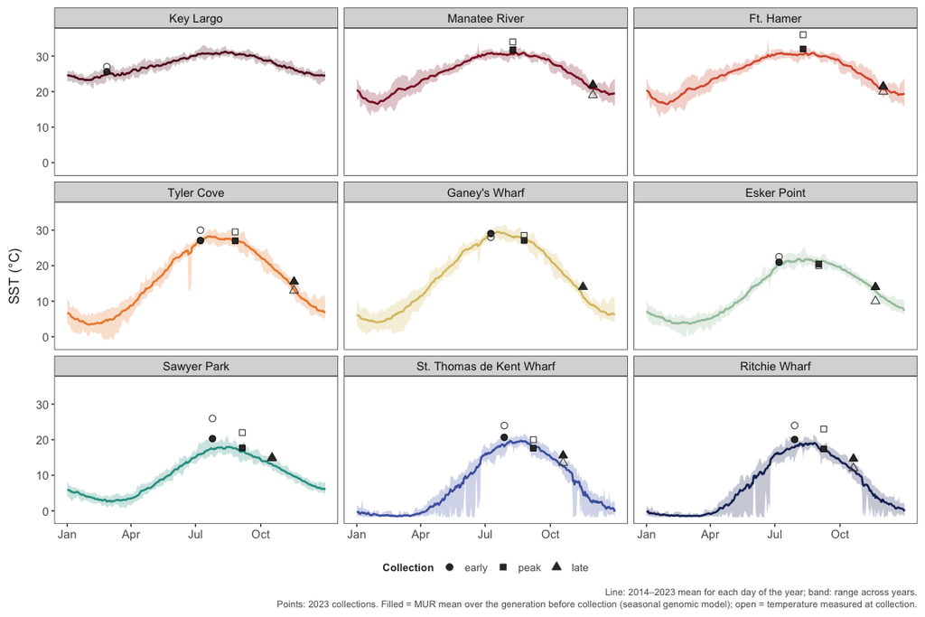

```r
mur_file <- od("mur_sst_daily_corrected.csv")
if (!file.exists(mur_file)) mur_file <- od("mur_sst_daily.csv")
if (!file.exists(mur_file)) {
  cat("MUR SST is not in Output_data yet (run Scripts/05_site_environment.R).")
} else {
  mur_daily <- read_csv(mur_file, show_col_types = FALSE) %>%
    mutate(doy = lubridate::yday(date), year = lubridate::year(date))
  site_lab <- c(KL = "Key Largo", site_names)
  site_lvls <- names(site_lab)[names(site_lab) %in% unique(mur_daily$site_code)]
  mur_cycle <- mur_daily %>%
    filter(doy <= 365) %>%
    group_by(site_code, doy) %>%
    summarise(mean = mean(sst_c), lo = min(sst_c), hi = max(sst_c), .groups = "drop") %>%
    mutate(site_code = factor(site_code, levels = site_lvls))
  seas_file <- od("seasonal_temperature.tsv")
  coll <- if (file.exists(seas_file)) {
    read_tsv(seas_file, show_col_types = FALSE) %>%
      mutate(doy = lubridate::yday(date), site_code = factor(site, levels = site_lvls),
             season = factor(season, levels = season_order)) %>%
      filter(!is.na(site_code))
  } else NULL

  p_cycle <- ggplot(mur_cycle, aes(x = doy)) +
    geom_ribbon(aes(ymin = lo, ymax = hi, fill = site_code), alpha = 0.25) +
    geom_line(aes(y = mean, colour = site_code), linewidth = 0.9) +
    facet_wrap(~ site_code, nrow = 3, labeller = as_labeller(site_lab)) +
    scale_colour_manual(values = pop_cols, guide = "none") +
    scale_fill_manual(values = pop_cols, guide = "none") +
    scale_x_continuous(breaks = c(1, 91, 182, 274), labels = c("Jan", "Apr", "Jul", "Oct")) +
    labs(x = NULL, y = "SST (°C)",
         caption = "Line: 2014–2023 mean for each day of the year; band: range across years.\nPoints: 2023 collections. Filled = MUR mean over the generation before collection (seasonal genomic model); open = temperature measured at collection.") +
    theme_matt_facets(base_size = 11)
  if (!is.null(coll)) {
    p_cycle <- p_cycle +
      geom_point(data = coll, aes(y = temp_c, shape = season), size = 2.5, fill = "grey20") +
      geom_point(data = coll, aes(y = temp_measured, shape = season), size = 2.5, colour = "grey30",
                 fill = NA, stroke = 0.6) +
      scale_shape_manual(values = c(early = 21, peak = 22, late = 24), name = "Collection") +
      theme(legend.position = "bottom")
  }
  p_cycle
}
```

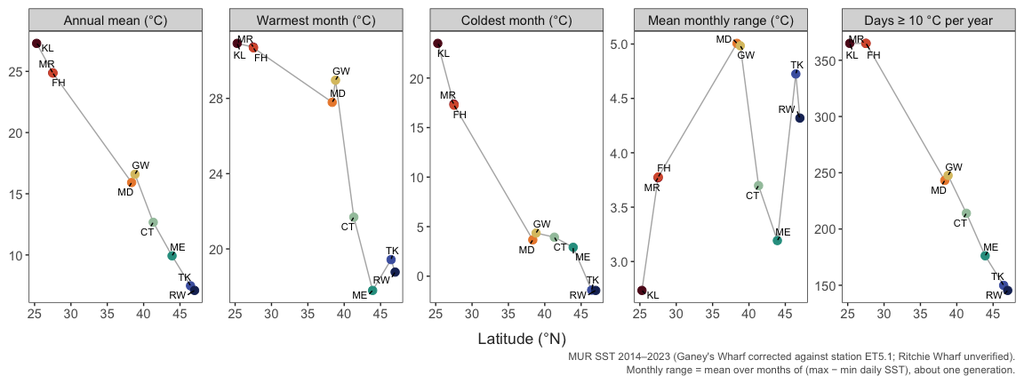

```r
clim_file <- od("site_climatology.csv")
if (file.exists(clim_file)) {
  site_clim <- read_csv(clim_file, show_col_types = FALSE)
  site_clim %>%
    select(site_code, lat, `Annual mean (°C)` = temp_mean, `Warmest month (°C)` = warmest_month,
           `Coldest month (°C)` = coldest_month, `Mean monthly range (°C)` = monthly_range,
           `Days ≥ 10 °C per year` = season_days) %>%
    pivot_longer(-c(site_code, lat), names_to = "metric", values_to = "value") %>%
    mutate(metric = factor(metric, levels = unique(metric))) %>%
    ggplot(aes(x = lat, y = value)) +
    geom_line(colour = "grey70") +
    geom_point(aes(colour = site_code), size = 3) +
    ggrepel::geom_text_repel(aes(label = site_code), size = 3, seed = 1, min.segment.length = 0) +
    facet_wrap(~ metric, nrow = 1, scales = "free_y") +
    scale_colour_manual(values = pop_cols, guide = "none") +
    labs(x = "Latitude (°N)", y = NULL,
         caption = "MUR SST 2014–2023 (Ganey's Wharf corrected against station ET5.1; Ritchie Wharf unverified).\nMonthly range = mean over months of (max − min daily SST), about one generation.") +
    theme_matt_facets(base_size = 11)
}
```

```r
if (file.exists(clim_file)) {
  site_clim %>%
    transmute(Site = site_code, `Lat (°N)` = lat, `Annual mean` = temp_mean, `Jun–Nov mean` = temp_season,
              `95th pct` = temp_p95, `Warmest month` = warmest_month, `Coldest month` = coldest_month,
              `Monthly range` = monthly_range, `Days ≥ 10 °C` = season_days,
              Note = case_when(site_code == "GW" ~ "corrected (ET5.1)", site_code == "RW" ~ "unverified", TRUE ~ "")) %>%
    knitr::kable(digits = 1, caption = "Site climatology from MUR SST, 2014–2023 (°C unless stated).")
}
```

Site climatology from MUR SST, 2014–2023 (°C unless stated).

| Site | Lat (°N) | Annual mean | Jun–Nov mean | 95th pct | Warmest month | Coldest month | Monthly range | Days ≥ 10 °C | Note |
| --- | --- | --- | --- | --- | --- | --- | --- | --- | --- |
| KL | 25.3 | 27.3 | 29.2 | 31.2 | 30.9 | 23.5 | 2.7 | 365.0 |  |
| MR | 27.5 | 24.9 | 28.3 | 31.1 | 30.7 | 17.4 | 3.8 | 365.0 |  |
| FH | 27.5 | 24.9 | 28.2 | 31.0 | 30.7 | 17.3 | 3.8 | 365.0 |  |
| MD | 38.4 | 15.9 | 22.8 | 28.2 | 27.8 | 3.7 | 5.0 | 243.2 |  |
| GW | 38.8 | 16.6 | 22.9 | 29.2 | 29.0 | 4.4 | 5.0 | 247.6 | corrected (ET5.1) |
| CT | 41.3 | 12.7 | 18.4 | 22.0 | 21.7 | 3.9 | 3.7 | 214.0 |  |
| ME | 43.9 | 9.9 | 14.4 | 18.0 | 17.8 | 2.9 | 3.2 | 176.2 |  |
| TK | 46.4 | 7.5 | 14.1 | 19.5 | 19.4 | -1.4 | 4.7 | 149.9 |  |
| RW | 47.0 | 7.1 | 13.5 | 18.9 | 18.8 | -1.4 | 4.3 | 145.4 | unverified |

### Paired low- and high-salinity sites

Nested within each of the three regions (South, Central, and Northern regions) are pairs of low and high salinity sites:

```r
data.frame("Region" = c("South", "Central", "North"),
           "Low Salinity" = c("Ft. Hamer", "Ganey's Wharf", "Ritchie Wharf"),
           "High Salinity" = c("Manatee River", "Tyler Cove", "St. Thomas de Kent Wharf")) %>%
  knitr::kable(align = "c")
```

| Region | Low.Salinity | High.Salinity |
| --- | --- | --- |
| South | Ft. Hamer | Manatee River |
| Central | Ganey’s Wharf | Tyler Cove |
| North | Ritchie Wharf | St. Thomas de Kent Wharf |

There are fairly well-established divergences between high salinity and low salinity populations of *Acartia tonsa*. These sets of geographically proximate sites potentially provide independent comparisons of the effects of seasonality across salinity gradients. Shown here are the collection conditions for these pairs of sites. Temperature was typically similar across the pairs within each collection, while salinity differences were fairly stable across collections.

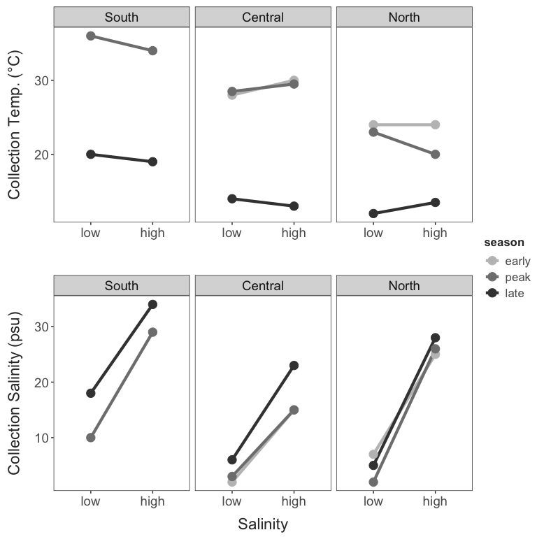

```r
season_cols = c("early" = "grey75",
                "peak" = "grey50",
                "late" = "grey25")

sal_regions = data.frame(region = rep(c("South", "Central", "North"), each = 2),
                         site = c("Ft. Hamer", "Manatee River",
                                  "Ganey's Wharf", "Tyler Cove",
                                  "Ritchie Wharf", "St. Thomas de Kent Wharf"),
                         salinity = c("low", "high"))

sal_comps = join_data %>%
  filter(site %in% sal_regions$site) %>%
  inner_join(sal_regions, by = c("site")) %>%
  select( region = region.y, site, salinity, season, doy, collection_temp, collection_salinity,
          size, ctmax, warming_tol) %>%
  mutate(salinity = fct_relevel(salinity, "low", "high"),
         region = fct_relevel(region, "South", "Central", "North"))

sal_comp_temps = sal_comps %>%
  select(salinity, season, region, collection_temp, collection_salinity) %>%
  distinct() %>%
  ggplot(aes(x = salinity, y = collection_temp, colour = season, group = season)) +
  facet_wrap(region~.) +
  geom_line(linewidth = 1.5) +
  geom_point(size = 4) +
  scale_colour_manual(values = season_cols) +
  labs(y = "Collection Temp. (°C)",
       x = "") +
  theme_matt_facets(base_size = 14)

sal_comp_sal = sal_comps %>%
  select(salinity, season, region, collection_temp, collection_salinity) %>%
  distinct() %>%
  ggplot(aes(x = salinity, y = collection_salinity, colour = season, group = season)) +
  facet_wrap(region~.) +
  geom_line(linewidth = 1.5) +
  geom_point(size = 4) +
  scale_colour_manual(values = season_cols) +
  labs(y = "Collection Salinity (psu)",
       x = "Salinity") +
  theme_matt_facets(base_size = 14)

ggarrange(sal_comp_temps, sal_comp_sal, nrow = 2, common.legend = T, legend = "right")
```

### Generations between collections

```r
early_peak = join_data %>%
  filter(season %in% c("early", "peak")) %>%
  mutate(season = if_else(season == "early", "one", "two")) %>%
  group_by(site) %>%
  mutate(ctmax_sd_p = sd(ctmax),
         size_sd_p = sd(size),
         temp_change = max(collection_temp) - min(collection_temp),
         avg_temp = (max(collection_temp) + min(collection_temp)) / 2,
         days_passed = max(doy) - min(doy)) %>%
  select(site, lat, season,
         ctmax_sd_p, size_sd_p,
         temp_change, avg_temp, days_passed,
         ctmax, size) %>%
  group_by(site, lat, season,
           ctmax_sd_p, size_sd_p,
           temp_change, avg_temp, days_passed) %>%
  summarize(ctmax = mean(ctmax),
            size = mean(size)) %>%
  pivot_wider(id_cols = c(site, lat, ctmax_sd_p, size_sd_p,
                          temp_change, avg_temp, days_passed),
              names_from = season,
              values_from = c(ctmax, size)) %>%
  mutate(season = "early_to_peak") %>%
  drop_na()

peak_late = join_data %>%
  filter(season %in% c("peak", "late")) %>%
  mutate(season = if_else(season == "peak", "one", "two")) %>%
  group_by(site) %>%
  mutate(ctmax_sd_p = sd(ctmax),
         size_sd_p = sd(size),
         temp_change = last(collection_temp) - first(collection_temp),
         avg_temp = (max(collection_temp) + min(collection_temp)) / 2,
         days_passed = max(doy) - min(doy)) %>%
  select(site, lat, season, ctmax_sd_p, size_sd_p,
         temp_change, avg_temp, days_passed,
         ctmax, size) %>%
  group_by(site, lat, season, ctmax_sd_p, size_sd_p,
           temp_change, avg_temp, days_passed) %>%
  summarize(ctmax = mean(ctmax),
            size = mean(size)) %>%
  pivot_wider(id_cols = c(site, lat, ctmax_sd_p, size_sd_p,
                          temp_change, avg_temp, days_passed),
              names_from = season,
              values_from = c(ctmax, size)) %>%
  mutate(season = "peak_to_late") %>%
  drop_na()


generations = bind_rows(early_peak, peak_late) %>%
  mutate("gen_time" = 5490*(avg_temp + 1)^-2.05,
         "gens" = floor(days_passed / gen_time))
```

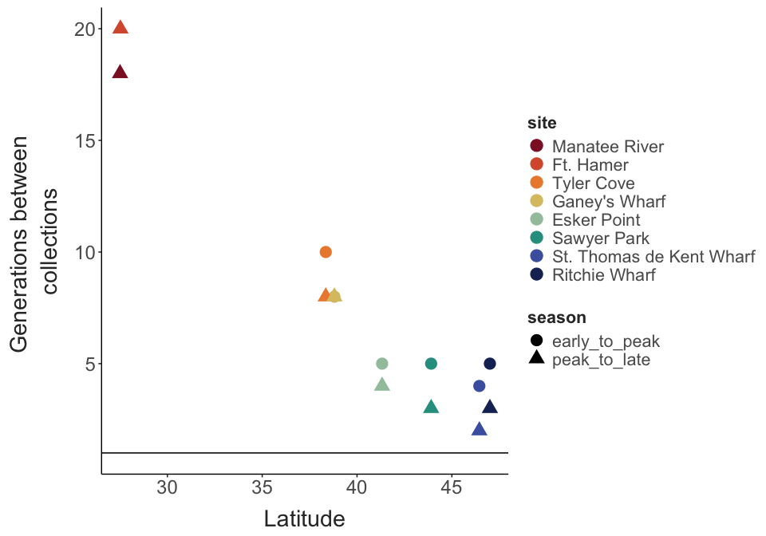

```r
ggplot(generations, aes(x = lat, y = gens, colour = site, shape = season)) +
  geom_hline(yintercept = 1) +
  geom_point(size = 5) +
  scale_colour_manual(values = site_cols) +
  labs(x = "Latitude",
       y = "Generations between \ncollections") +
  scale_y_continuous(breaks = seq(from = 0, to = 21, by = 5)) +
  theme_matt() +
  theme(legend.position = "right")
```

## 2. Phenotypes: thermal limits and body size

### Critical Thermal Limits

A total of 427 individuals were examined. Critical thermal limits and body size measurements were made before individuals were preserved in ethanol. We excluded data for individuals that were either later classified as males or juveniles, that we were unable to assign to a clade, or that were identified as individuals from a closely related species (*Acartia hudsonica*). With these individuals excluded, the full data set contains 395 adult females with CTmax and body size measurements, and clade identifications.

Critical thermal maxima (CTmax) was measured using a custom setup. The method uses a standard dynamic ramping assay to determine the maximum temperature individuals could sustain normal functioning. This differs from lethal temperatures, and indeed, all individuals recovered following the assay.

Individuals were rested for one hour after collection before the assay. During the assay, copepods were held in artificial seawater, composed of bottled spring water and Instant Ocean salt mix adjusted to match collection salinities. During the assay, several ‘control’ individuals were maintained in this solution at ambient temperatures without the temperature ramp to ensure that there was no background changes in behavior or mortality. When sorting individuals from the plankton tow contents, they were held in a 50:50 mix of 60 um filtered water from the collection site and artificial seawater as an additional acclimation step.

Sample sizes varied slightly across experiments, but generally ~20 individuals were measured per season at each site. The major exceptions were the early samples from the Florida sites and the late sample from Sawyer Park (Maine). Only two sets of samples (peak and late) were collected from Fort Hamer and Manatee River. The late season collection from Sawyer Park occurred after *Acartia tonsa* abundance decreased, and samples were dominated by *Acartia hudsonica*. Thermal limits were measured for all *A. tonsa* individuals recovered. No samples were collected from Key Largo for this project, as *Acartia tonsa* wasn’t present in the water during the peak season, likely due to a recent extreme heat event.

```r
join_data %>%
  group_by(site, season) %>%
  count() %>%
  pivot_wider(id_cols = "site",
              names_from = season,
              values_from = n,
              values_fill = 0) %>%
  select(site, early, peak, late) %>%
  knitr::kable()
```

| site | early | peak | late |
| --- | --- | --- | --- |
| Manatee River | 0 | 17 | 20 |
| Ft. Hamer | 0 | 19 | 19 |
| Tyler Cove | 20 | 19 | 20 |
| Ganey’s Wharf | 20 | 20 | 20 |
| Esker Point | 17 | 19 | 20 |
| Sawyer Park | 14 | 17 | 8 |
| St. Thomas de Kent Wharf | 15 | 19 | 19 |
| Ritchie Wharf | 16 | 18 | 19 |

Shown below are the measured CTmax values. Individual measurements are shown in small points for each collection. The large points indicate the mean values for each collection.

```r
mean_ctmax = join_data %>%
  filter(clade!="A_hudsonica") %>%
  group_by(site, season, doy, collection_temp) %>%
  summarize(mean_ctmax = mean(ctmax),
            median_ctmax = median(ctmax))

ctmax_plot = join_data %>%
  filter(clade!="A_hudsonica") %>%
  ggplot(aes(x = season, y = ctmax, colour = site)) +
  geom_line(data = mean_ctmax,
            aes(y = mean_ctmax, group = site),
            position = position_dodge(width = 0.4),
            linewidth = 1) +
  geom_point(position = position_jitterdodge(jitter.width = 0.1, jitter.height = 0,
                                             dodge.width = 0.4),
             alpha = 0.3) +
  geom_point(data = mean_ctmax,
             aes(y = mean_ctmax),
             position = position_dodge(width = 0.4),
             size = 4) +
  scale_colour_manual(values = site_cols) +
  labs(y = "CTmax (°C)",
       x = "Season") +
  theme_matt() +
  theme(legend.position = "right",
        legend.title.align = 0.125)
```

### Body Size

Following the CTmax assay, individuals were photographed for body size measurements. Prosome lengths were measured from these photographs using a scale micrometer and the software ImageJ. These measurements are shown below. As before, large points indicate the mean body size. While less cohesive than CTmax, a general trend of increasing body size with latitude and time of year can be seen.

```r
mean_size = join_data %>%
  filter(clade != "A_hudsonica") %>%
  group_by(site, season, doy, collection_temp) %>%
  summarize(mean_size = mean(size),
            median_size = median(size))

size_plot = join_data %>%
  filter(clade != "A_hudsonica") %>%
  ggplot(aes(x = season, y = size, colour = site)) +
  geom_line(data = mean_size,
            aes(y = mean_size, group = site),
            position = position_dodge(width = 0.4),
            linewidth = 1) +
  geom_point(position = position_jitterdodge(jitter.width = 0.1, jitter.height = 0,
                                             dodge.width = 0.4),
             alpha = 0.3) +
  geom_point(data = mean_size,
             aes(y = mean_size),
             position = position_dodge(width = 0.4),
             size = 4) +
  scale_colour_manual(values = site_cols) +
  labs(y = "Prosome Length (mm)",
       x = "Season") +
  theme_matt() +
  theme(legend.position = "right",
        legend.title.align = 0.125)
```

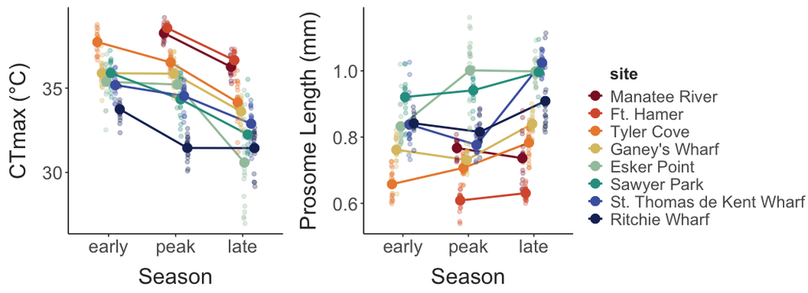

```r
ggarrange(ctmax_plot, size_plot, common.legend = T, legend = "right")
```

### Warming tolerance

Warming tolerance (the difference between thermal limits and environmental temperatures) is a commonly used metric of climate vulnerability. We calculated this as the difference between measured CTmax values and the collection temperature. Smaller warming tolerance values indicate that populations were nearer to their upper thermal limits, suggesting greater vulnerability.

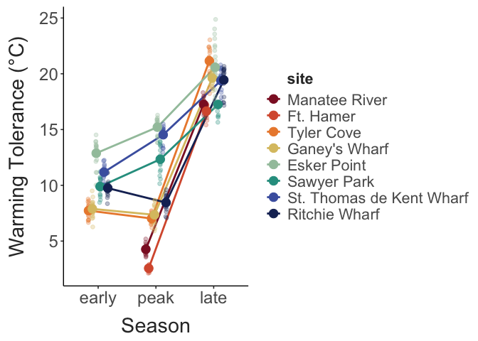

```r
mean_wt = join_data %>%
  filter(clade!="A_hudsonica") %>%
  group_by(site, season) %>%
  summarize(mean_wt = mean(warming_tol),
            median_wt = median(warming_tol))

ggplot(join_data, aes(x = season, y = warming_tol, colour = site)) +
  geom_line(data = mean_wt,
            aes(y = mean_wt, group = site),
            position = position_dodge(width = 0.4),
            linewidth = 1) +
  geom_point(position = position_jitterdodge(jitter.width = 0.1, jitter.height = 0,
                                             dodge.width = 0.4),
             alpha = 0.3) +
  geom_point(data = mean_wt,
             aes(y = mean_wt),
             position = position_dodge(width = 0.4),
             size = 4) +
  scale_colour_manual(values = site_cols) +
  labs(y = "Warming Tolerance (°C)",
       x = "Season") +
  theme_matt() +
  theme(legend.position = "right",
        legend.title.align = 0.125)
```

### Trait correlations

Regardless of the underlying mechanism (genetic differentiation or phenotypic plasticity), we expect that collections from warmer waters should yield copepods with higher thermal limits and smaller body sizes. Our observations largely fit this expectation, with strong increases in CTmax at higher temperatures, and a general decrease in prosome lengths as temperature increased. There was a larger correlation between CTmax and temperature than size and temperature. There are myriad reasons this might be observed, but one potential is the potential for acclimation of thermal limits. Body size is fixed in the adult stage, while CTmax can continue to vary as water temperature changes. This is indirect evidence for the importance of rapid acclimation in the observed patterns.

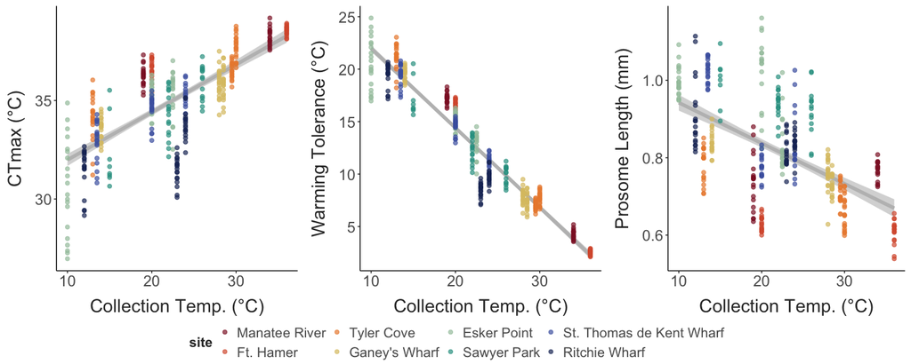

```r
# join_data %>%
#   filter(clade != "A_hudsonica") %>%
#   group_by(site, season, collection_temp) %>%
#   summarise(mean_ctmax = mean(ctmax),
#             se_ctmax = sd(ctmax) / sqrt(n())) %>%
#   ggplot(aes(x = collection_temp, y = mean_ctmax)) +
#   geom_smooth(method = "lm", se = T,
#               linewidth = 2,
#               colour = "grey") +
#   geom_errorbar(aes(ymin = mean_ctmax - se_ctmax, ymax = mean_ctmax + se_ctmax, colour = site)) +
#   geom_point(aes(colour = site),
#              size = 3) +
#   scale_colour_manual(values = site_cols) +
#   labs(y = "CTmax (°C)",
#        x = "Collection Temp. (°C)") +
#   theme_matt() +
#   theme(legend.position = "none")

ctmax_temp_plot = join_data %>%
  filter(clade != "A_hudsonica") %>%
  ggplot(aes(x = collection_temp, y = ctmax)) +
  geom_smooth(method = "lm", se = T,
              linewidth = 2,
              colour = "grey") +
  geom_point(aes(colour = site),
             size = 2, alpha = 0.7) +
  scale_colour_manual(values = site_cols) +
  labs(y = "CTmax (°C)",
       x = "Collection Temp. (°C)") +
  theme_matt() +
  theme(legend.position = "none")

size_temp_plot = join_data %>%
  filter(clade != "A_hudsonica") %>%
  ggplot(aes(x = collection_temp, y = size)) +
  geom_smooth(method = "lm", se = T,
              linewidth = 2,
              colour = "grey") +
  geom_point(aes(colour = site),
             size = 2, alpha = 0.7) +
  scale_colour_manual(values = site_cols) +
  labs(y = "Prosome Length (mm)",
       x = "Collection Temp. (°C)") +
  theme_matt() +
  theme(legend.position = "right")

wt_temp_plot = join_data %>%
  filter(clade != "A_hudsonica") %>%
  ggplot(aes(x = collection_temp, y = warming_tol)) +
  geom_smooth(method = "lm", se = T,
              linewidth = 2,
              colour = "grey") +
  geom_point(aes(colour = site),
             size = 2, alpha = 0.7) +
  scale_colour_manual(values = site_cols) +
  labs(y = "Warming Tolerance (°C)",
       x = "Collection Temp. (°C)") +
  theme_matt() +
  theme(legend.position = "right")

ggarrange(ctmax_temp_plot, wt_temp_plot, size_temp_plot, common.legend = T, legend = "bottom", nrow = 1)
```

The relationship between prosome length and CTmax is also of interest. Given that larger body sizes are associated with cold adaptation/acclimation, it is unsurprising that there is a general trend of decreasing thermal limits with increasing size. Individual regression lines for each site are also included - the dark grey lines in the background represent the ‘universal’ regression for that site, with individual colored regression lines for each collection. At most sites, evidence for this negative relationship between CTmax and body size is observed across collections rather than within collections, suggesting this relationship is primaly a reflection of the response to seasonal temperature variation.

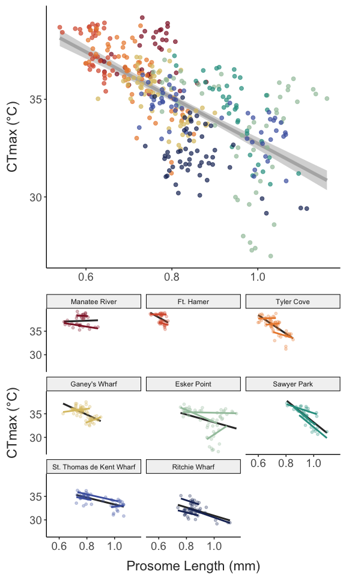

```r
universal_size = join_data %>%
  filter(clade != "A_hudsonica") %>%
  ggplot(aes(x = size, y = ctmax)) +
  # geom_smooth(data = filter(full_data, ctmax > 31),
  #             aes(x = size, y = ctmax),
  #             method = "lm",
  #             colour = "grey60",
  #             se = F,
  #             linewidth = 2) +
  geom_smooth(method = "lm", se = T,
              linewidth = 2,
              colour = "grey70") +
  geom_point(aes(colour = site),
             size = 2, alpha = 0.7) +
  scale_colour_manual(values = site_cols) +
  labs(y = "CTmax (°C)",
       x = "") +
  theme_matt(base_size = 14) +
  theme(legend.position = "right",
        axis.title.x = element_blank())

pop_size = join_data %>%
  filter(clade != "A_hudsonica") %>%
  ggplot(aes(x = size, y = ctmax, colour = site, group = season)) +
  facet_wrap(site~.) +
  # geom_smooth(data = filter(full_data, ctmax > 31),
  #             aes(x = size, y = ctmax),
  #             method = "lm",
  #             colour = "grey60",
  #             se = F,
  #             linewidth = 2) +
  geom_smooth(data = join_data,
              aes(x = size, y = ctmax, group = site),
              colour = "grey20", method = "lm", se = F) +
  geom_point(size = 1.3, alpha = 0.3) +
  geom_smooth(method = "lm", se = F,
              linewidth = 1) +
  scale_colour_manual(values = site_cols) +
  scale_x_continuous(breaks = c(0.6, 0.8, 1)) +
  labs(y = "CTmax (°C)",
       x = "Prosome Length (mm)") +
  theme_matt(base_size = 14) +
  theme(legend.position = "right")

ggarrange(universal_size, pop_size, common.legend = T, legend = "none", nrow = 2)
```

### Paired sites: trait differences

The three pairs of cross-salinity comparisons do show evidence for fine-scale trait divergence, although there was no consistent pattern in the direction or magnitude of differences. CTmax was similar across sites in the Southern and Central pairs. In the Northern pair, CTmax tended to be slightly lower for individuals from the low salinity site. Size was more variable between the paired sites. In the South, individuals from the low salinity site were consistently smaller than individuals from the high salinity site, despite experiencing similar temperatures. By contrast, in the Central pair individuals from the low salinity site tended to be slightly larger than those from the high salinity site, although the magnitude of this difference this varied seasonally. In the Northern pair, individuals from the low salinity site were slightly larger than individuals from the high salinity site during the early and peak season collections, but there was an abrupt reversal of this pattern during the late collection, when individuals from the high salinity site were much larger than individuals from the low salinity site.

Note that two of the three pairs also differ in clade composition: Manatee River and Ft. Hamer hold different F lineages (F-MR, F-FH), and St. Thomas de Kent Wharf and Ritchie Wharf differ in their mix of clades X and IV (Section 3). Differences between paired sites therefore combine environment, lineage and clade composition; Section 4 separates them.

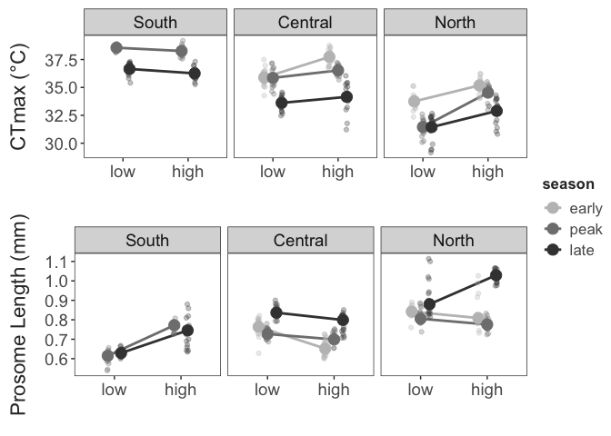

```r
sal_means = sal_comps %>%
  group_by(region, site, salinity, season) %>%
  summarize(mean_ctmax = mean(ctmax),
            mean_size = median(size))

sal_comp_ctmax_plot = sal_comps %>%
  ggplot(aes(x = salinity, y = ctmax, colour = season, group = season)) +
  facet_wrap(region~.) +
  geom_line(data = sal_means,
            aes(y = mean_ctmax, group = season),
            position = position_dodge(width = 0.4),
            linewidth = 1) +
  geom_point(position = position_jitterdodge(jitter.width = 0.1, jitter.height = 0,
                                             dodge.width = 0.4),
             alpha = 0.3) +
  geom_point(data = sal_means,
             aes(y = mean_ctmax),
             position = position_dodge(width = 0.4),
             size = 4) +
  scale_colour_manual(values = season_cols) +
  labs(y = "CTmax (°C)",
       x = "") +
  theme_matt_facets(base_size = 14)

sal_comp_size_plot = sal_comps %>%
  ggplot(aes(x = salinity, y = size, colour = season, group = season)) +
  facet_wrap(region~.) +
  geom_line(data = sal_means,
            aes(y = mean_size, group = season),
            position = position_dodge(width = 0.4),
            linewidth = 1) +
  geom_point(position = position_jitterdodge(jitter.width = 0.1, jitter.height = 0,
                                             dodge.width = 0.4),
             alpha = 0.3) +
  geom_point(data = sal_means,
             aes(y = mean_size),
             position = position_dodge(width = 0.4),
             size = 4) +
  scale_colour_manual(values = season_cols) +
  labs(y = "Prosome Length (mm)",
       x = "") +
  theme_matt_facets(base_size = 14)

ggarrange(sal_comp_ctmax_plot, sal_comp_size_plot, nrow = 2, common.legend = T, legend = "right")
```

### Assay checks

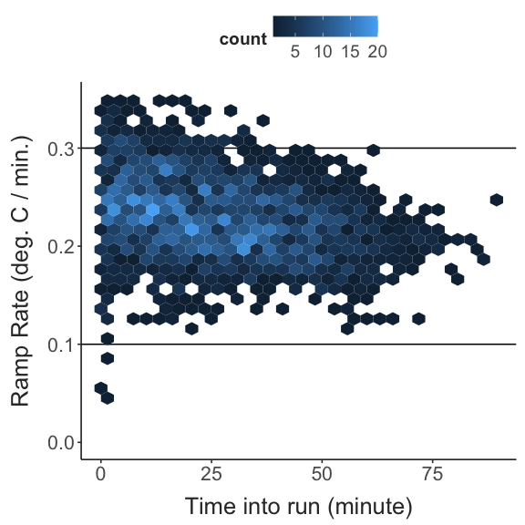

```r
ramp_record2 = ramp_record %>%
  group_by(run, minute_interval) %>%
  summarise(mean_ramp = mean(ramp_per_minute)) %>%
  ungroup()

ggplot(ramp_record2, aes(x = minute_interval, y = mean_ramp)) +
  geom_hline(yintercept = 0.3) +
  geom_hline(yintercept = 0.1) +
  #geom_point() +
  geom_hex(bins = 30) +
  ylim(0, 0.35) +
  labs(y = "Ramp Rate (deg. C / min.)",
       x = "Time into run (minute)") +
  theme_matt(base_size = 16)
```

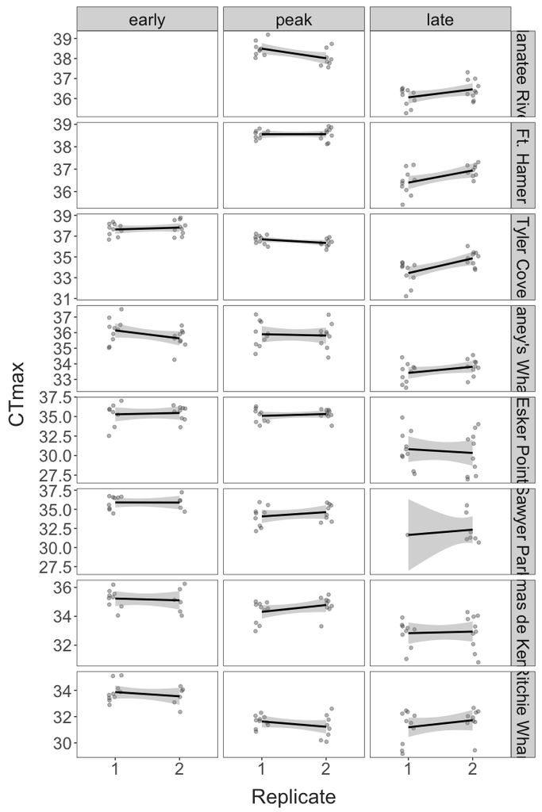

```r
join_data %>%
  drop_na(replicate) %>%
  ggplot(aes(x = factor(replicate), y = ctmax, group = site)) +
  facet_grid(site~season, scales = "free_y") +
  geom_point(position = position_jitter(width = 0.1, height = 0),
             alpha = 0.4,
             colour = "grey30") +
  geom_smooth(method = "lm", colour = "black") +
  labs(x = "Replicate",
       y = "CTmax") +
  theme_matt_facets()
```

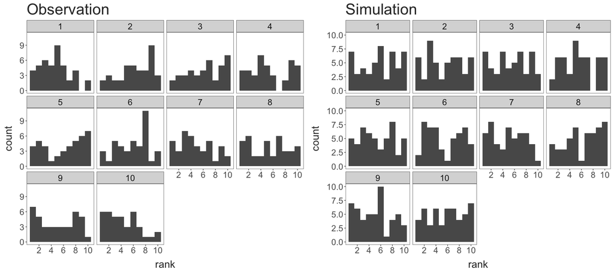

```r
obs_ranks = ggplot(join_data, aes(x = rank)) +
  facet_wrap(tube~.) +
  geom_histogram(binwidth = 1) +
  scale_x_continuous(breaks = c(2,4,6,8,10)) +
  ggtitle("Observation") +
  theme_matt_facets()

sim_data = data.frame()
for(i in 1:50){
  rep_data = data.frame("tube" = sample(c(1:10), size = 10, replace = F),
                        "rank" = c(1:10),
                        "rep" = i) %>%
    arrange(tube)

  sim_data = bind_rows(sim_data, rep_data)

}

sim_ranks = ggplot(sim_data, aes(x = rank)) +
  facet_wrap(tube~.) +
  geom_histogram(binwidth = 1) +
  scale_x_continuous(breaks = c(2,4,6,8,10)) +
  ggtitle("Simulation") +
  theme_matt_facets()


ggarrange(obs_ranks, sim_ranks)
```

## 3. Low-coverage whole genome data

After phenotyping, each individual was preserved in 95% ethanol. Individual DNA libraries were prepared using Twist Bio 96-plex prep kits, then sequenced on two lanes of an Illumina NovaSeq X Plus 25B by Novogene (436 libraries). Read processing, mapping, site filtering, clade assignment and population genomic analyses were run on the Unity cluster (Snakemake project `aton_lcwg`). The figures in this section are built from the exported result tables (`Raw_data/cluster_exports/`; export in use: aton_lcwg_tables_2026-10-31). *Acartia hudsonica* libraries are excluded throughout.

### Sequencing summary

Reads per library varied over two orders of magnitude; 23 libraries failed (< 500,000 reads, 20 of them on plate 5). The reference genome is closest to clade X: the other clades map less well and yield less usable depth per read, on every plate. Libraries with low mapping and high GC content carry DNA from other organisms (Section 3.3).

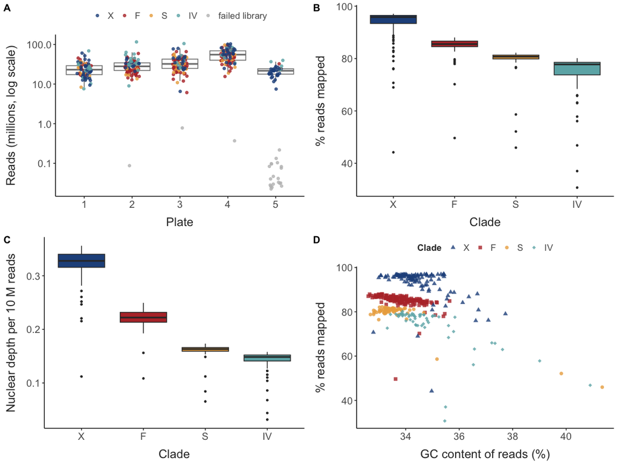

```r
p_reads <- ggplot(seq_plot, aes(x = factor(plate), y = raw_reads / 1e6)) +
  geom_boxplot(data = ~ filter(.x, !library_failed), outlier.shape = NA, colour = "grey50") +
  geom_jitter(aes(colour = status), width = 0.15, height = 0, size = 1.5, alpha = 0.8) +
  scale_colour_manual(values = status_cols) +
  scale_y_log10() +
  labs(x = "Plate", y = "Reads (millions, log scale)", colour = NULL) +
  theme_matt(base_size = 14)

p_map <- seq_plot %>% filter(!library_failed, clade %in% tonsa_clades) %>%
  ggplot(aes(x = factor(clade, levels = tonsa_clades), y = pct_mapped, fill = clade)) +
  geom_boxplot(outlier.size = 1) +
  scale_fill_manual(values = clade_cols, guide = "none") +
  labs(x = "Clade", y = "% reads mapped") +
  theme_matt(base_size = 14)

p_bias <- seq_plot %>% filter(!library_failed, clade %in% tonsa_clades) %>%
  ggplot(aes(x = factor(clade, levels = tonsa_clades), y = depth_per_10M, fill = clade)) +
  geom_boxplot(outlier.size = 1) +
  scale_fill_manual(values = clade_cols, guide = "none") +
  labs(x = "Clade", y = "Nuclear depth per 10 M reads") +
  theme_matt(base_size = 14)

p_gc <- seq_plot %>% filter(!library_failed, clade %in% tonsa_clades) %>%
  mutate(clade = factor(clade, levels = tonsa_clades)) %>%
  ggplot(aes(x = 100 * gc_after, y = pct_mapped, colour = clade, shape = clade)) +
  geom_point(size = 2, alpha = 0.8) +
  scale_colour_manual(values = clade_cols) +
  scale_shape_manual(values = clade_shapes) +
  labs(x = "GC content of reads (%)", y = "% reads mapped", colour = "Clade", shape = "Clade") +
  theme_matt(base_size = 14)

ggarrange(p_reads, p_map, p_bias, p_gc, ncol = 2, nrow = 2, labels = "AUTO")
```

There is no clear relationship between the number of reads and individual size or CTmax (phenotype analysis set only).

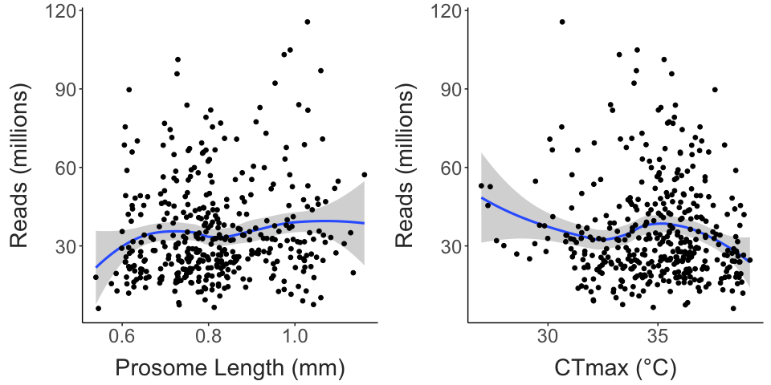

```r
reads_size_plot = ggplot(join_data, aes(x = size, y = raw_reads / 1e6)) +
  geom_smooth() +
  geom_point() +
  labs(x = "Prosome Length (mm)", y = "Reads (millions)") +
  theme_matt()

reads_ctmax_plot = ggplot(join_data, aes(x = ctmax, y = raw_reads / 1e6)) +
  geom_smooth() +
  geom_point() +
  labs(x = "CTmax (°C)", y = "Reads (millions)") +
  theme_matt()

ggarrange(reads_size_plot, reads_ctmax_plot, nrow = 1)
```

```r
read.model = lm(data = join_data, raw_reads ~ size + ctmax)
knitr::kable(car::Anova(read.model))
```

|  | Sum Sq | Df | F value | Pr(>F) |
| --- | --- | --- | --- | --- |
| size | 9.603839e+14 | 1 | 2.6795203 | 0.1024488 |
| ctmax | 1.671663e+11 | 1 | 0.0004664 | 0.9827809 |
| Residuals | 1.404992e+17 | 392 | NA | NA |

### Site filtering

Genotype-likelihood analyses use only the 15 chromosomes, minus soft-masked repeats, nuclear copies of mitochondrial DNA (NUMTs) and SNPs flagged as collapsed paralogs by ngsParalog. Because of the reference bias, far fewer sites pass the missing-data filter (data in at least 50% of individuals) in clades S and IV than in X.

[figure not shown]

```r
genome_mb <- 779.75
cascade <- tibble(
  step = c("Assembly", "15 chromosomes", "Repeats removed", "Final sites"),
  mb = c(genome_mb, sum(unmask$length) / 1e6, sum(unmask$unmasked_bp) / 1e6,
         sum(final_s$unmasked_bp) / 1e6)) %>%
  mutate(step = factor(step, levels = step))

p_cascade <- ggplot(cascade, aes(x = step, y = mb)) +
  geom_col(fill = "grey60", width = 0.7) +
  geom_text(aes(label = sprintf("%.0f", mb)), vjust = -0.4, size = 4) +
  labs(x = NULL, y = "Megabases") +
  theme_matt(base_size = 13) +
  theme(axis.text.x = element_text(angle = 20, hjust = 1))

p_access <- depth_c %>%
  filter(clade %in% tonsa_clades) %>%
  mutate(clade = factor(clade, levels = tonsa_clades)) %>%
  ggplot(aes(x = clade, y = sites_counted / 1e6, fill = clade)) +
  geom_col(width = 0.7) +
  scale_fill_manual(values = clade_cols, guide = "none") +
  labs(x = "Clade", y = "Mb with data in ≥ 50%\nof individuals") +
  theme_matt(base_size = 13)

p_paralog <- paralog %>%
  filter(clade %in% tonsa_clades) %>%
  mutate(clade = factor(clade, levels = tonsa_clades)) %>%
  ggplot(aes(x = clade, y = pct_flagged, fill = clade)) +
  geom_col(width = 0.7) +
  scale_fill_manual(values = clade_cols, guide = "none") +
  labs(x = "Clade", y = "% candidate SNPs flagged\nas paralogs") +
  theme_matt(base_size = 13)

ggarrange(p_cascade, p_access, p_paralog, nrow = 1, labels = "AUTO", widths = c(1.3, 1, 1))
```

### Clade identity

Clades were assigned in two independent ways. **Mitochondrial:** each individual’s reads were mapped to one partial mitogenome per clade, and the clade was taken from the reads covering the COI barcode region. **Nuclear:** genome-wide genotype likelihoods (PCAngsd, NGSadmix) on all kept libraries. The two agree for every individual. Two libraries contained DNA from individuals of two different clades (both mitochondrial and nuclear signals mixed) and were excluded.

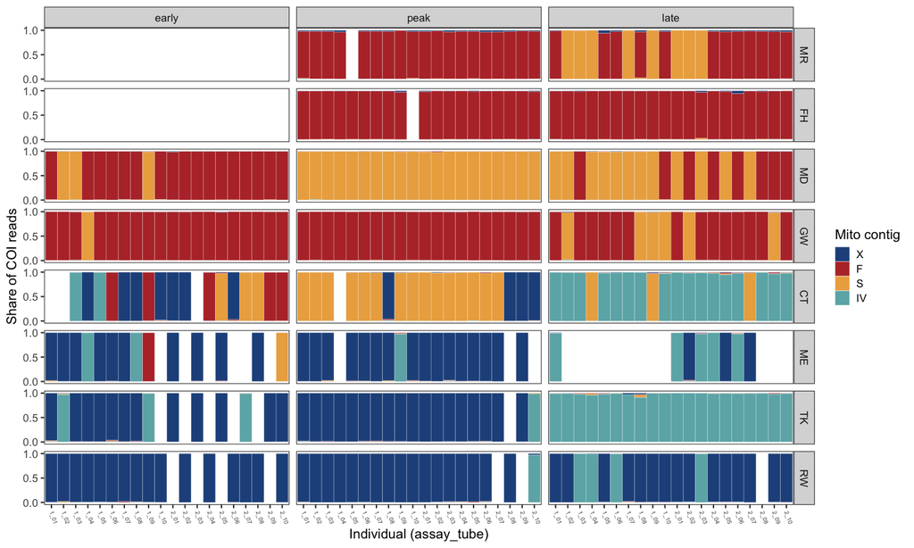

```r
mito_long <- mito %>%
  select(sample_id, starts_with("coi_reads_mtDNA_")) %>%
  pivot_longer(-sample_id, names_to = "contig", values_to = "reads",
               names_prefix = "coi_reads_mtDNA_") %>%
  group_by(sample_id) %>%
  mutate(prop = reads / sum(reads)) %>%
  ungroup() %>%
  inner_join(select(seq_data, sample_id, site_code, season, replicate, tube), by = "sample_id") %>%
  mutate(contig = factor(contig, levels = tonsa_clades),
         ind = sprintf("%d_%02d", replicate, tube))

ggplot(mito_long, aes(x = ind, y = prop, fill = contig)) +
  facet_grid(site_code ~ season) +
  geom_col(width = 1, colour = "white", linewidth = 0.1) +
  scale_fill_manual(values = clade_cols) +
  scale_y_continuous(breaks = c(0, 0.5, 1)) +
  labs(x = "Individual (assay_tube)", y = "Share of COI reads", fill = "Mito contig") +
  theme_bw(base_size = 16) +
  theme(panel.grid = element_blank(),
        axis.text.x = element_text(angle = 290, hjust = 0, vjust = 0.5, size = 7))
```

All four clades are cleanly separated in the nuclear genome. Clade F splits further into site-specific sub-lineages (Manatee River, Ft. Hamer, and the Chesapeake/New England group), visible on PC4 and at K = 5–6.

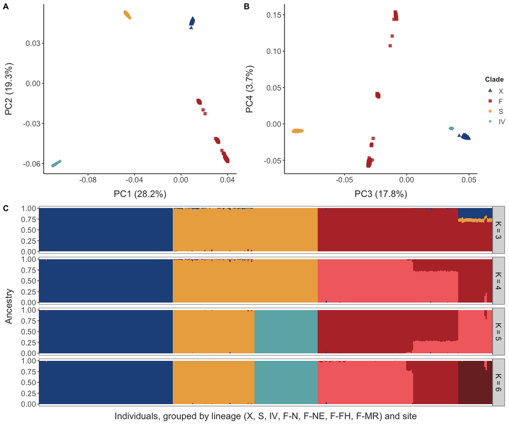

```r
pca_full <- read_cx("results", "04_structure", "all", "pcangsd_scores.tsv")
cov_all <- as.matrix(read.table(cx("results", "04_structure", "all", "pcangsd.cov")))
ve <- eigen(cov_all, symmetric = TRUE, only.values = TRUE)$values
ve <- round(100 * ve / sum(ve), 1)

# PCAngsd / NGSadmix were run on all kept libraries; the two mixed (unassigned)
# libraries are dropped from the plots only
pca_full <- pca_full %>%
  left_join(select(clades, sample_id, clade, lineage), by = "sample_id")
pca_all <- pca_full %>%
  filter(clade %in% tonsa_clades) %>%
  mutate(clade = factor(clade, levels = tonsa_clades))

pca_plot <- function(a, b) {
  ggplot(pca_all, aes(x = .data[[a]], y = .data[[b]], colour = clade, shape = clade)) +
    geom_point(size = 2.2, alpha = 0.85) +
    scale_colour_manual(values = clade_cols[tonsa_clades]) +
    scale_shape_manual(values = clade_shapes[tonsa_clades]) +
    labs(x = sprintf("%s (%.1f%%)", a, ve[as.integer(sub("PC", "", a))]),
         y = sprintf("%s (%.1f%%)", b, ve[as.integer(sub("PC", "", b))]),
         colour = "Clade", shape = "Clade") +
    theme_matt(base_size = 13)
}

# NGSadmix: best of 3 runs per K; clusters coloured by the clade that dominates them
best_run <- function(K) {
  likes <- sapply(1:3, function(r) {
    l <- readLines(cx("results", "04_structure", "all", "ngsadmix", sprintf("K%d_rep%d.log", K, r)))
    as.numeric(sub(".*best like=([-0-9.e]+).*", "\\1", grep("best like", l, value = TRUE)[1]))
  })
  which.max(likes)
}
ord <- pca_all %>%
  mutate(lin = factor(lineage, levels = c("X", "S", "IV", "F-N", "F-NE", "F-FH", "F-MR")),
         site_code = factor(site, levels = site_order)) %>%
  arrange(lin, site_code, sampling_event) %>% pull(sample_id)
f_shades <- c(clade_cols[["F"]], "#F36E6D", "#7C2B2B", "#FFB3B2")   # F plus lighter / darker shades
admix <- map_dfr(3:6, function(K) {
  q <- read.table(cx("results", "04_structure", "all", "ngsadmix", sprintf("K%d_rep%d.qopt", K, best_run(K))))
  q$sample_id <- pca_full$sample_id   # rows follow the full analysis set
  long <- pivot_longer(q, -sample_id, names_to = "cluster", values_to = "q") %>%
    filter(sample_id %in% pca_all$sample_id)
  dom <- long %>% group_by(sample_id) %>% slice_max(q, n = 1, with_ties = FALSE) %>% ungroup() %>%
    left_join(select(pca_all, sample_id, clade), by = "sample_id") %>%
    count(cluster, clade) %>% group_by(cluster) %>% slice_max(n, n = 1, with_ties = FALSE)
  long %>% left_join(select(dom, cluster, top = clade), by = "cluster") %>% mutate(K = paste0("K = ", K))
}) %>%
  mutate(sample_id = factor(sample_id, levels = ord))
fill_map <- admix %>% distinct(K, cluster, top) %>% group_by(K, top) %>%
  mutate(col = if_else(top == "F", f_shades[row_number()], clade_cols[as.character(top)])) %>%
  ungroup() %>% mutate(key = paste(K, cluster))
admix <- admix %>% mutate(key = paste(K, cluster))

p_admix <- ggplot(admix, aes(x = sample_id, y = q, fill = key)) +
  facet_grid(K ~ .) +
  geom_col(width = 1) +
  scale_fill_manual(values = setNames(fill_map$col, fill_map$key), guide = "none") +
  labs(x = "Individuals, grouped by lineage (X, S, IV, F-N, F-NE, F-FH, F-MR) and site", y = "Ancestry") +
  theme_matt_facets(base_size = 13) +
  theme(axis.text.x = element_blank(), axis.ticks.x = element_blank())

ggarrange(ggarrange(pca_plot("PC1", "PC2"), pca_plot("PC3", "PC4"), nrow = 1,
                    common.legend = TRUE, legend = "right", labels = c("A", "B")),
          p_admix, nrow = 2, heights = c(1, 1.1), labels = c("", "C"))
```

Within clade F, the sub-lineages are clearly separated (2–6% COI divergence) but much less divergent than the clades are from each other (12–18%). We therefore analyse four clades, and keep the F sub-lineage as an annotation.

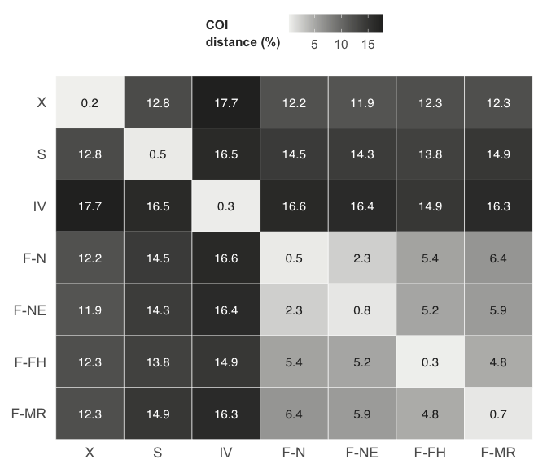

```r
fa <- readLines(cx("results", "03_clades", "mito", "coi_aligned.fa"))
hdr <- grepl("^>", fa)
seq_id <- sub("^>(\\S+).*", "\\1", fa[hdr])
seqs <- tapply(fa[!hdr], cumsum(hdr)[!hdr], paste, collapse = "")
names(seqs) <- seq_id
lin <- clades %>% filter(clade %in% tonsa_clades, sample_id %in% seq_id) %>%
  mutate(group = if_else(clade == "F", lineage, clade))
mat <- do.call(rbind, strsplit(toupper(seqs[lin$sample_id]), ""))
ok <- matrix(mat %in% c("A", "C", "G", "T"), nrow = nrow(mat))
n <- nrow(mat); diff <- matrix(0, n, n); comp <- matrix(0, n, n)
for (j in seq_len(ncol(mat))) {
  v <- ok[, j]
  both <- outer(v, v, "&")
  comp <- comp + both
  diff <- diff + (outer(mat[, j], mat[, j], "!=") & both)
}
pd <- diff / comp
grp <- lin$group
grp_levels <- intersect(c("X", "S", "IV", "F-N", "F-NE", "F-FH", "F-MR"), unique(grp))
div <- expand_grid(a = grp_levels, b = grp_levels) %>%
  mutate(pdist = map2_dbl(a, b, function(x, y) {
    m <- pd[grp == x, grp == y, drop = FALSE]
    if (x == y) mean(m[upper.tri(m)]) else mean(m)
  }) * 100,
  a = factor(a, levels = grp_levels), b = factor(b, levels = rev(grp_levels)))

ggplot(div, aes(x = a, y = b, fill = pdist)) +
  geom_tile(colour = "white") +
  geom_text(aes(label = sprintf("%.1f", pdist), colour = pdist > 9), size = 4) +
  scale_colour_manual(values = c("TRUE" = "white", "FALSE" = "grey15"), guide = "none") +
  scale_fill_gradient(low = "#F2F2F0", high = "#2B2B29", name = "COI\ndistance (%)") +
  labs(x = NULL, y = NULL) +
  theme_matt(base_size = 13) +
  theme(axis.line = element_blank(), axis.ticks = element_blank())
```

#### Lineage phylogeny: mitochondrial vs nuclear

Mitochondrial relationships come from the COI maximum-likelihood tree (IQ-TREE, all individuals and reference haplotypes), reduced to one representative per lineage (the individual with the most complete COI sequence) and rooted on *A. hudsonica*. Support values are ultrafast bootstraps of the corresponding node in the full tree. Nuclear relationships come from genome-wide individual covariances (PCAngsd, all individuals): pairwise distances d<sub>ij</sub> = C<sub>ii</sub> + C<sub>jj</sub> − 2C<sub>ij</sub> were averaged between lineages and corrected for within-lineage distance (net distance), and a neighbour-joining tree was built from them (midpoint-rooted; support = percentage of 200 bootstrap replicates resampling individuals within lineages).

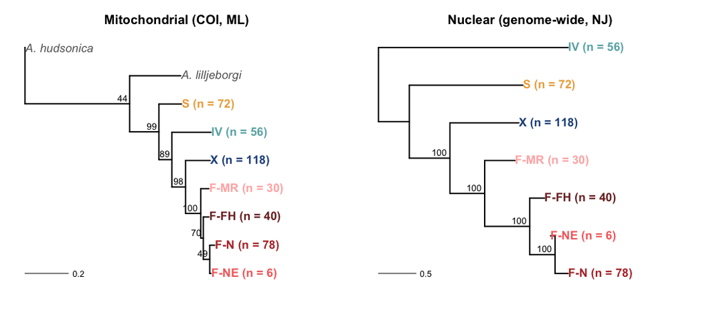

```r
lin_levels <- c("X", "S", "IV", "F-N", "F-NE", "F-FH", "F-MR")
lin_col <- c(X = clade_cols[["X"]], S = clade_cols[["S"]], IV = clade_cols[["IV"]],
             `F-N` = f_shades[1], `F-NE` = f_shades[2], `F-FH` = f_shades[3], `F-MR` = f_shades[4])
lin_n <- clades %>% filter(lineage %in% lin_levels) %>% count(lineage)

# mitochondrial: COI tree reduced to one tip per lineage plus outgroups
coi_tr <- ape::read.tree(cx("results", "03_clades", "mito", "coi_tree.contree"))
coi_miss <- read_cx("results", "03_clades", "mito", "coi_missingness.tsv")
reps <- coi_miss %>%
  filter(included == "yes", flag == "ok", sample_id %in% coi_tr$tip.label) %>%
  inner_join(select(clades, sample_id, lineage), by = "sample_id") %>%
  filter(lineage %in% lin_levels) %>%
  group_by(lineage) %>% slice_min(frac_missing, n = 1, with_ties = FALSE) %>% ungroup()
outg <- c(A_hudsonica = grep("A_hudsonica", coi_tr$tip.label, value = TRUE)[1],
          A_lilljeborgi = grep("A_lilljeborgi", coi_tr$tip.label, value = TRUE)[1])
hud <- grep("A_hudsonica", coi_tr$tip.label, value = TRUE)
coi_full <- ape::root(coi_tr, outgroup = hud, resolve.root = TRUE)
coi_red <- ape::keep.tip(coi_full, c(reps$sample_id, outg))
# support: label of the matching node (same descendant tips' MRCA) in the full tree
full_sup <- suppressWarnings(as.numeric(coi_full$node.label))
coi_red$node.label <- map_chr(seq_len(coi_red$Nnode) + ape::Ntip(coi_red), function(nd) {
  tips <- coi_red$tip.label[phangorn::Descendants(coi_red, nd, "tips")[[1]]]
  if (length(tips) == ape::Ntip(coi_red)) return("")
  m <- ape::getMRCA(coi_full, tips)
  v <- full_sup[m - ape::Ntip(coi_full)]
  if (is.na(v)) "" else as.character(round(v))
})
lab_of <- c(set_names(reps$lineage, reps$sample_id), set_names(c("A. hudsonica", "A. lilljeborgi"), outg))
coi_red$tip.label <- unname(lab_of[coi_red$tip.label])
coi_red <- ape::ladderize(coi_red)

# nuclear: net distances between lineages from the PCAngsd covariance
pc_ids <- read_cx("results", "04_structure", "all", "pcangsd_scores.tsv")$sample_id
Cm <- as.matrix(read.table(cx("results", "04_structure", "all", "pcangsd.cov")))
dimnames(Cm) <- list(pc_ids, pc_ids)
nuc_ind <- clades %>% filter(sample_id %in% pc_ids, lineage %in% lin_levels)
Dind <- outer(diag(Cm), diag(Cm), "+") - 2 * Cm
net_dist <- function(ids_by_lin) {
  L <- names(ids_by_lin)
  w <- map_dbl(ids_by_lin, function(i) { m <- Dind[i, i]; mean(m[upper.tri(m)]) })
  D <- outer(L, L, Vectorize(function(a, b)
    if (a == b) 0 else mean(Dind[ids_by_lin[[a]], ids_by_lin[[b]]]) - (w[[a]] + w[[b]]) / 2))
  dimnames(D) <- list(L, L)
  D
}
by_lin <- split(nuc_ind$sample_id, factor(nuc_ind$lineage, levels = lin_levels))
nuc_tr <- phangorn::midpoint(ape::nj(net_dist(by_lin)))
set.seed(1)
boots <- map(1:200, function(b) {
  bl <- map(by_lin, ~ sample(.x, length(.x), replace = TRUE))
  phangorn::midpoint(ape::nj(net_dist(bl)))
})
nuc_tr$node.label <- round(100 * ape::prop.clades(nuc_tr, boots) / length(boots))
nuc_tr$node.label[1] <- ""
nuc_tr <- ape::ladderize(nuc_tr)

tip_cols <- function(tr) unname(c(lin_col, `A. hudsonica` = "grey40", `A. lilljeborgi` = "grey40")[tr$tip.label])
tip_lab <- function(tr) {
  n <- lin_n$n[match(tr$tip.label, lin_n$lineage)]
  ifelse(is.na(n), tr$tip.label, sprintf("%s (n = %d)", tr$tip.label, n))
}
op <- par(mfrow = c(1, 2), mar = c(3, 1, 3, 1))
for (k in 1:2) {
  tr <- if (k == 1) coi_red else nuc_tr
  tr2 <- tr; tr2$tip.label <- tip_lab(tr)
  ape::plot.phylo(tr2, tip.color = tip_cols(tr), font = ifelse(grepl("^A\\.", tr$tip.label), 3, 2),
                  cex = 1.1, label.offset = 0.002 * (k == 1) + 0.00002 * (k == 2), edge.width = 2,
                  x.lim = c(0, max(ape::node.depth.edgelength(tr)) * 1.6),
                  main = c("Mitochondrial (COI, ML)", "Nuclear (genome-wide, NJ)")[k])
  ape::nodelabels(tr$node.label, frame = "none", adj = c(1.2, -0.4), cex = 0.85)
  ape::add.scale.bar(cex = 0.8)
}
```

```r
par(op)
```

The two genomes give the same tree. Unrooted, both split the clades into {S, IV} and {X, F}, with X sister to F (support 98 in COI, 100 in the nuclear tree), and both order the F lineages the same way: F-MR first, then F-FH, then F-N with F-NE. They differ only in where the root falls, and the nuclear root is a midpoint placement, not an estimate. Mito-nuclear concordance at every level means the lineages are not mitochondrial types introgressed onto a shared nuclear background: they are separate, non-interbreeding (or rarely interbreeding) genetic units. Nuclear distances from the PCAngsd covariance summarise genome-wide divergence rather than coming from a substitution model, so branch lengths in the two panels are not comparable.

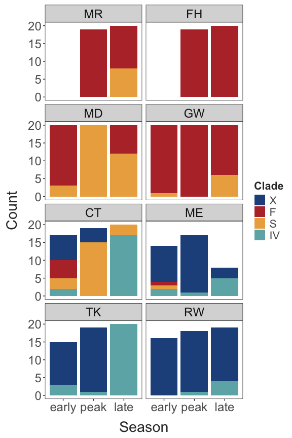

```r
seq_data %>%
  filter(clade %in% tonsa_clades) %>%
  mutate(clade = factor(clade, levels = tonsa_clades)) %>%
  droplevels() %>%
  ggplot(aes(x = season, fill = clade)) +
  facet_wrap(site_code ~ ., ncol = 2) +
  geom_bar() +
  scale_fill_manual(values = clade_cols) +
  labs(x = "Season", y = "Count", fill = "Clade") +
  theme_matt_facets(base_size = 18)
```

#### Seasonal turnover of lineages

Lineage composition is compared among the collections at each site (sequenced individuals only; unassigned libraries excluded). Each site gets a Fisher exact test of lineage × season (simulated p, 10⁴ replicates). The combined test uses the sum of per-site χ² statistics, with season labels shuffled among individuals within each site (10⁴ permutations); sites with a single lineage contribute nothing.

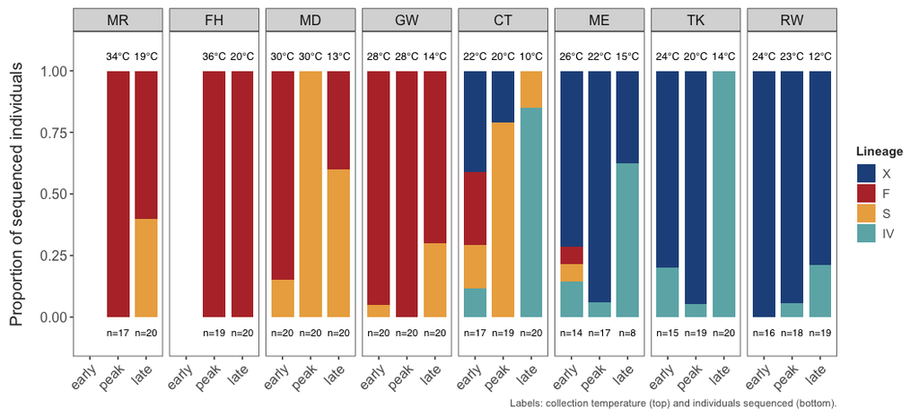

```r
season_levels <- c("early", "peak", "late")
# analysis unit = clade (the F lineages are analysed together); column kept as `lineage` for the code below
unit_levels <- tonsa_clades
unit_col <- clade_cols[tonsa_clades]
comp <- seq_data %>%
  filter(clade %in% unit_levels, !sample_id %in% c("MR_peak_2_04", "MR_peak_2_05")) %>%
  mutate(season = factor(season, levels = season_levels),
         lineage = factor(clade, levels = unit_levels),
         site_code = factor(site_code, levels = site_order))
coll_temp <- comp %>% group_by(site_code, season) %>%
  summarise(temp = mean(collection_temp, na.rm = TRUE), n = n(), .groups = "drop")

chi_stat <- function(lin, sea) {
  tb <- table(droplevels(lin), droplevels(sea))
  if (nrow(tb) < 2 || ncol(tb) < 2) return(0)
  suppressWarnings(unname(chisq.test(tb, correct = FALSE)$statistic))
}
set.seed(1)
turn_site <- comp %>% group_by(site_code) %>%
  summarise(seasons = n_distinct(season), lineages = n_distinct(lineage), individuals = n(),
            p = if (n_distinct(season) > 1 && n_distinct(lineage) > 1)
              fisher.test(table(droplevels(lineage), droplevels(season)), simulate.p.value = TRUE, B = 1e4)$p.value
            else NA_real_,
            .groups = "drop")
obs_chi <- comp %>% group_by(site_code) %>% summarise(x = chi_stat(lineage, season)) %>% pull(x) %>% sum()
by_site <- split(comp, comp$site_code, drop = TRUE)
perm_chi <- replicate(1e4, sum(map_dbl(by_site, ~ chi_stat(.x$lineage, sample(.x$season)))))
turn_p <- (sum(perm_chi >= obs_chi) + 1) / (length(perm_chi) + 1)

ggplot(comp, aes(x = season, fill = lineage)) +
  geom_bar(position = "fill", width = 0.8) +
  geom_text(data = coll_temp, aes(x = season, y = 1.06, label = sprintf("%.0f°C", temp)),
            inherit.aes = FALSE, size = 3.2) +
  geom_text(data = coll_temp, aes(x = season, y = -0.06, label = paste0("n=", n)),
            inherit.aes = FALSE, size = 3) +
  facet_wrap(~ site_code, nrow = 1) +
  scale_fill_manual(values = unit_col, drop = FALSE) +
  scale_y_continuous(breaks = seq(0, 1, 0.25), limits = c(-0.1, 1.1)) +
  labs(x = NULL, y = "Proportion of sequenced individuals", fill = "Lineage",
       caption = "Labels: collection temperature (top) and individuals sequenced (bottom).") +
  theme_matt_facets(base_size = 12) +
  theme(axis.text.x = element_text(angle = 45, hjust = 1))
```

```r
turn_site %>%
  left_join(comp %>% group_by(site_code, season) %>% count(lineage) %>%
              summarise(comp = paste(sprintf("%s %d", lineage, n), collapse = ", "), .groups = "drop") %>%
              group_by(site_code) %>%
              summarise(composition = paste(sprintf("%s: %s", season, comp), collapse = "; ")),
            by = "site_code") %>%
  transmute(Site = site_code, Seasons = seasons, Lineages = lineages, Individuals = individuals,
            `Fisher p` = if_else(is.na(p), "–", format.pval(p, digits = 2, eps = 1e-4)),
            Composition = composition) %>%
  knitr::kable(caption = sprintf("Lineage composition by season at each site. Combined test across sites: χ² = %.0f, permutation p %s.",
                                 obs_chi, format.pval(turn_p, digits = 2, eps = 1e-4)))
```

Lineage composition by season at each site. Combined test across sites: χ² = 166, permutation p <1e-04.

| Site | Seasons | Lineages | Individuals | Fisher p | Composition |
| --- | --- | --- | --- | --- | --- |
| MR | 2 | 2 | 37 | 0.0039 | peak: F 17; late: F 12, S 8 |
| FH | 2 | 1 | 39 | – | peak: F 19; late: F 20 |
| MD | 3 | 2 | 60 | <1e-04 | early: F 17, S 3; peak: S 20; late: F 8, S 12 |
| GW | 3 | 2 | 60 | 0.0132 | early: F 19, S 1; peak: F 20; late: F 14, S 6 |
| CT | 3 | 4 | 56 | <1e-04 | early: X 7, F 5, S 3, IV 2; peak: X 4, S 15; late: S 3, IV 17 |
| ME | 3 | 4 | 39 | 0.0081 | early: X 10, F 1, S 1, IV 2; peak: X 16, IV 1; late: X 3, IV 5 |
| TK | 3 | 2 | 54 | <1e-04 | early: X 12, IV 3; peak: X 18, IV 1; late: IV 20 |
| RW | 3 | 2 | 53 | 0.1141 | early: X 16; peak: X 17, IV 1; late: X 15, IV 4 |

### Genetic differentiation within clades

Population structure and diversity are analysed within each clade (X, F, S, IV), with populations defined as clade × site × sampling event (n ≥ 8). Within clade F, site differences include differences between F sub-lineages.

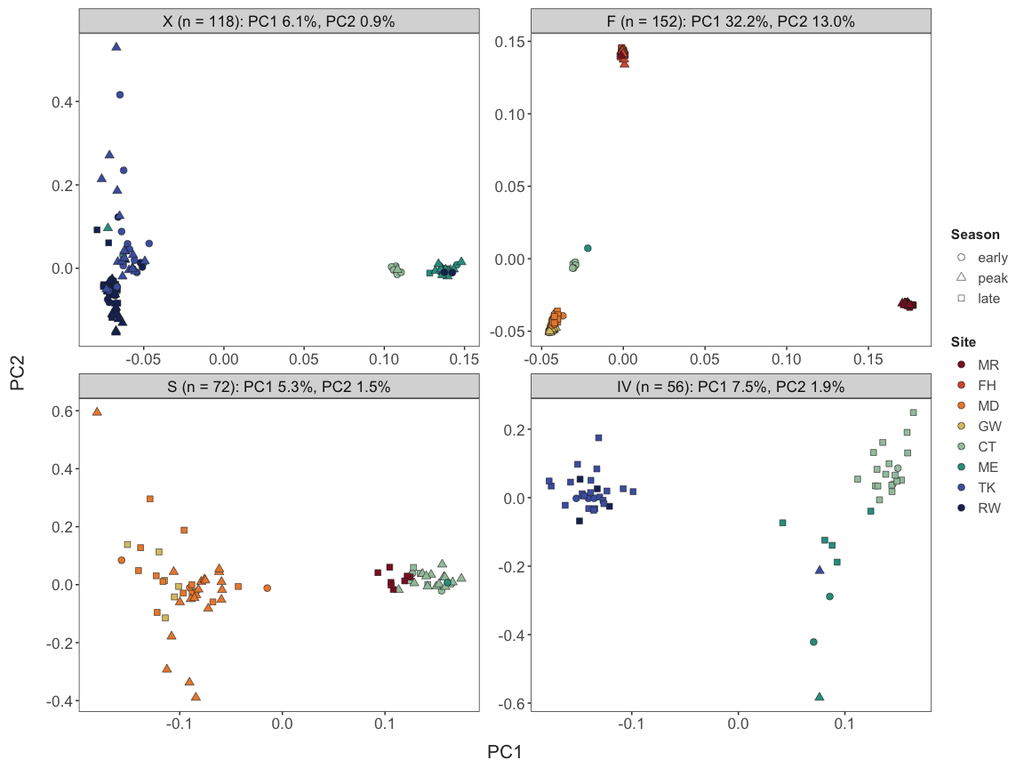

```r
wpca <- map_dfr(tonsa_clades, function(cl) {
  f <- cx("results", "04_structure", cl, "pcangsd_scores.tsv")
  if (!file.exists(f)) return(NULL)
  cv <- as.matrix(read.table(cx("results", "04_structure", cl, "pcangsd.cov")))
  v <- eigen(cv, symmetric = TRUE, only.values = TRUE)$values
  read_tsv(f, show_col_types = FALSE) %>%
    transmute(sample_id, PC1, PC2, site, season = sampling_event,
              panel = sprintf("%s (n = %d): PC1 %.1f%%, PC2 %.1f%%", cl, n(), 100 * v[1] / sum(v), 100 * v[2] / sum(v)))
})
if (nrow(wpca) == 0) {
  cat("Within-clade PCAs are not in this export yet.")
} else {
  wpca %>%
    mutate(site = factor(site, levels = site_order),
           season = factor(season, levels = season_order),
           panel = factor(panel, levels = unique(panel))) %>%
    ggplot(aes(x = PC1, y = PC2, fill = site, shape = season)) +
    facet_wrap(~ panel, scales = "free") +
    geom_point(size = 2.5, colour = "grey15", stroke = 0.3) +
    # 95% ellipse per site (t distribution, so a few outlying individuals don't
    # inflate it); sites with fewer than 4 individuals in a clade get no ellipse
    # stat_ellipse(data = ~ add_count(.x, panel, site) %>% filter(n >= 4),
    #              aes(x = PC1, y = PC2, colour = site, group = site), inherit.aes = FALSE,
    #              type = "t", level = 0.95, linewidth = 0.7) +
    scale_colour_manual(values = pop_cols[site_order], guide = "none") +
    scale_fill_manual(values = pop_cols[site_order], drop = FALSE) +
    scale_shape_manual(values = c(early = 21, peak = 24, late = 22)) +
    guides(fill = guide_legend(override.aes = list(shape = 21))) +
    labs(fill = "Site", shape = "Season") +
    theme_matt_facets(base_size = 13)
}
```

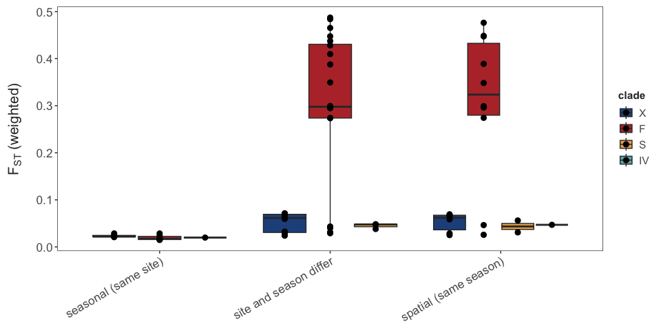

```r
fst_files <- Sys.glob(cx("results", "05_diversity", "fst", "*.fst.global.txt"))
if (length(fst_files) == 0) {
  cat("FST results are not in this export yet.")
} else {
  fst <- map_dfr(fst_files, function(f) {
    vals <- as.numeric(regmatches(readLines(f, warn = FALSE), gregexpr("-?[0-9.]+(e-?[0-9]+)?", readLines(f, warn = FALSE)))[[1]])
    pops <- strsplit(sub("\\.fst\\.global\\.txt$", "", basename(f)), ".vs.", fixed = TRUE)[[1]]
    tibble(pop1 = pops[1], pop2 = pops[2], fst_unweighted = tail(vals, 2)[1], fst_weighted = tail(vals, 1))
  }) %>%
    separate(pop1, c("clade", "site1", "season1"), sep = "__") %>%
    separate(pop2, c("clade2", "site2", "season2"), sep = "__") %>%
    filter(clade %in% tonsa_clades) %>%
    mutate(comparison = case_when(site1 == site2 ~ "seasonal (same site)",
                                  season1 == season2 ~ "spatial (same season)",
                                  TRUE ~ "site and season differ"),
           clade = factor(clade, levels = tonsa_clades))
  write_csv(fst, here("Output", "Output_data", "fst_pairs.csv"))
  ggplot(fst, aes(x = comparison, y = fst_weighted, fill = clade)) +
    geom_boxplot(position = position_dodge(width = 0.8)) +
    geom_point(size = 2.5, position = position_dodge(width = 0.8)) +
    scale_fill_manual(values = clade_cols) +
    labs(x = NULL, y = expression(F[ST]~"(weighted)")) +
    theme_matt_facets(base_size = 13) +
    theme(axis.text.x = element_text(angle = 30, hjust = 1))
}
```

#### Isolation by distance

Genetic differentiation between sites within each clade, against the straight-line distance between sites. F<sub>ST</sub> is averaged over the season pairs available for each pair of sites. F pairs between sub-lineages (F-MR, F-FH, F-N) are shown separately: they reflect divergence between lineages, not gene flow between populations. Straight-line distances underestimate the distance by sea (around Florida, and around Nova Scotia between Maine and the Gulf of St. Lawrence), and each clade has only 2–4 sites, so this is descriptive.

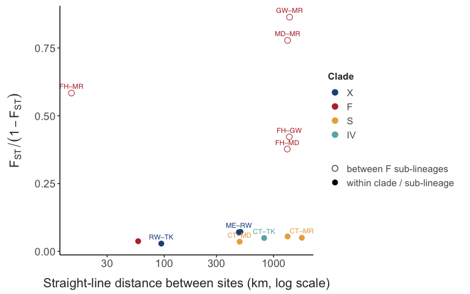

```r
if (exists("fst") && nrow(fst) > 0) {
  haversine_km <- function(lat1, lon1, lat2, lon2) {
    rad <- pi / 180
    a <- sin((lat2 - lat1) * rad / 2)^2 + cos(lat1 * rad) * cos(lat2 * rad) * sin((lon2 - lon1) * rad / 2)^2
    2 * 6371 * asin(sqrt(a))
  }
  f_lineage <- c(MR = "F-MR", FH = "F-FH", MD = "F-N", GW = "F-N")
  coords <- site_data %>% distinct(site_code, lat, long)
  ibd <- fst %>%
    filter(site1 != site2) %>%
    mutate(a = pmin(site1, site2), b = pmax(site1, site2)) %>%
    group_by(clade, a, b) %>%
    summarise(fst = mean(fst_weighted), n_pairs = n(), .groups = "drop") %>%
    left_join(rename(coords, a = site_code, lat_a = lat, long_a = long), by = "a") %>%
    left_join(rename(coords, b = site_code, lat_b = lat, long_b = long), by = "b") %>%
    mutate(dist_km = haversine_km(lat_a, long_a, lat_b, long_b),
           fst_lin = fst / (1 - fst),
           comparison = if_else(clade == "F" & f_lineage[a] != f_lineage[b],
                                "between F sub-lineages", "within clade / sub-lineage"),
           label = paste(a, b, sep = "–"))
  write_csv(ibd, here("Output", "Output_data", "isolation_by_distance.csv"))
  ggplot(ibd, aes(x = dist_km, y = fst_lin, colour = clade, shape = comparison)) +
    geom_point(size = 3) +
    geom_text(aes(label = label), size = 3, vjust = -0.9, check_overlap = TRUE, show.legend = FALSE) +
    scale_x_log10() +
    scale_colour_manual(values = clade_cols[tonsa_clades]) +
    scale_shape_manual(values = c("within clade / sub-lineage" = 16, "between F sub-lineages" = 1)) +
    labs(x = "Straight-line distance between sites (km, log scale)", y = expression(F[ST] / (1 - F[ST])),
         colour = "Clade", shape = NULL) +
    theme_matt(base_size = 13) +
    theme(legend.position = "right")
} else {
  cat("FST results are not in this export yet.")
}
```

Shown below are estimates of diversity across the data set. Tajima’s D can be used to detect random vs. non-random evolutionary processes (e.g. drift vs. selection). A value near zero indicates neutral processes and a stable population size. Negative values indicate an excess of rare alleles, suggesting possible recent selective sweeps or population expansion after a bottleneck. Positive values indicate possible population contraction or balancing selection, resulting in fewer rare alleles than expected.

We note that these diversity metrics should only be compared within clades since reference bias changes which sites are usable in each clade.

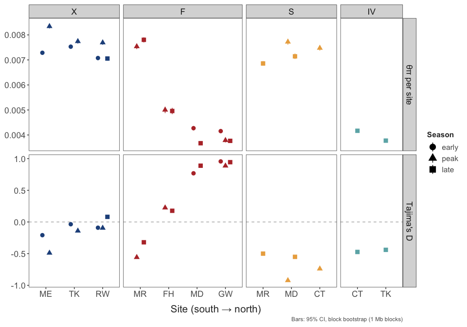

```r
# Genome-wide theta_W, theta_pi and Tajima's D per population, with 95% CIs.
# Preferred: block bootstrap over 1 Mb blocks (diversity_ci.tsv, rule tajima_boot).
# Fallback for older exports: delete-one-chromosome jackknife (15 blocks, crude)
# from the per-chromosome thetaStat output. D is always computed from summed
# thetas, not by averaging per-block D.
tajima_D <- function(tw, tp, n_ind) {
  nchr <- 2 * n_ind
  i <- seq_len(nchr - 1)
  a1 <- sum(1 / i); a2 <- sum(1 / i^2)
  b1 <- (nchr + 1) / (3 * (nchr - 1)); b2 <- 2 * (nchr^2 + nchr + 3) / (9 * nchr * (nchr - 1))
  c1 <- b1 - 1 / a1; c2 <- b2 - (nchr + 2) / (a1 * nchr) + a2 / a1^2
  e1 <- c1 / a1; e2 <- c2 / (a1^2 + a2)
  S <- tw * a1
  (tp - tw) / sqrt(e1 * S + e2 * S * (S - 1))
}
jackknife_pop <- function(pop, n_ind) {
  f <- cx("results", "05_diversity", "thetas", paste0(pop, ".thetas.idx.pestPG"))
  if (!file.exists(f)) return(NULL)
  t <- read.table(f, comment.char = "", skip = 1)
  tw <- t[[4]]; tp <- t[[5]]; ns <- t[[14]]; g <- length(ns)
  est <- function(keep) c(tajima_D(sum(tw[keep]), sum(tp[keep]), n_ind),
                          sum(tp[keep]) / sum(ns[keep]), sum(tw[keep]) / sum(ns[keep]))
  full <- est(rep(TRUE, g))
  loo <- sapply(seq_len(g), function(j) est(seq_len(g) != j))
  se <- sqrt((g - 1) / g * rowSums((loo - rowMeans(loo))^2))
  tibble(population = pop, n_ind = n_ind, n_sites = sum(ns),
         tajima_D = full[1], tajima_D_lo95 = full[1] - 1.96 * se[1], tajima_D_hi95 = full[1] + 1.96 * se[1],
         pi = full[2], pi_lo95 = full[2] - 1.96 * se[2], pi_hi95 = full[2] + 1.96 * se[2],
         theta_W = full[3], ci_method = "chromosome jackknife (15 blocks)")
}

ci_file  <- cx("results", "05_diversity", "diversity_ci.tsv")
pop_file <- cx("results", "05_diversity", "populations.tsv")
if (file.exists(ci_file)) {
  div_pop <- read_tsv(ci_file, show_col_types = FALSE) %>%
    mutate(ci_method = "block bootstrap (1 Mb blocks)")
} else if (file.exists(pop_file)) {
  pops <- read_tsv(pop_file, show_col_types = FALSE)
  div_pop <- map2_dfr(pops$population, pops$n, jackknife_pop)
} else {
  div_pop <- tibble()
}

if (nrow(div_pop) == 0) {
  cat("Diversity estimates are not in this export yet.")
} else {
  div_pop <- div_pop %>%
    separate(population, c("clade", "site", "season"), sep = "__", remove = FALSE) %>%
    filter(clade %in% tonsa_clades) %>%
    mutate(clade = factor(clade, levels = tonsa_clades),
           site = factor(site, levels = site_order),
           season = factor(season, levels = season_order))
  write_csv(div_pop, here("Output", "Output_data", "diversity_populations.csv"))
  div_pop %>%
    transmute(clade, site, season,
              `θπ per site_est` = pi, `θπ per site_lo` = pi_lo95, `θπ per site_hi` = pi_hi95,
              `Tajima's D_est` = tajima_D, `Tajima's D_lo` = tajima_D_lo95, `Tajima's D_hi` = tajima_D_hi95) %>%
    pivot_longer(-c(clade, site, season), names_to = c("stat", ".value"), names_sep = "_(?=[^_]+$)") %>%
    mutate(stat = factor(stat, levels = c("θπ per site", "Tajima's D"))) %>%
    ggplot(aes(x = site, y = est, ymin = lo, ymax = hi, shape = season, colour = clade)) +
    facet_grid(stat ~ clade, scales = "free", space = "free_x") +
    geom_hline(data = tibble(stat = factor("Tajima's D", levels = c("θπ per site", "Tajima's D")), y = 0), aes(yintercept = y),
               inherit.aes = FALSE, colour = "grey70", linetype = "dashed") +
    geom_pointrange(position = position_dodge(width = 0.5), size = 1, fatten = 2.5) +
    scale_colour_manual(values = clade_cols, guide = "none") +
    scale_shape_manual(values = c(early = 16, peak = 17, late = 15)) +
    labs(x = "Site (south → north)", y = NULL, shape = "Season",
         caption = paste("Bars: 95% CI,", unique(div_pop$ci_method))) +
    theme_matt_facets(base_size = 13)
}
```

LD was estimated with ngsLD within each clade on every fifth SNP (MAF ≥ 0.05), for a random 2% of SNP pairs up to 100 kb apart, and averaged in distance bins. Dashed lines show the r² expected between unlinked SNPs from sample size alone (≈ 1/n). LD decays to near that level within a few kb in X, S and IV, as expected for very large long-term population sizes. The higher plateau in F reflects allele-frequency differences between the F sub-lineages pooled in the clade, not physical linkage.

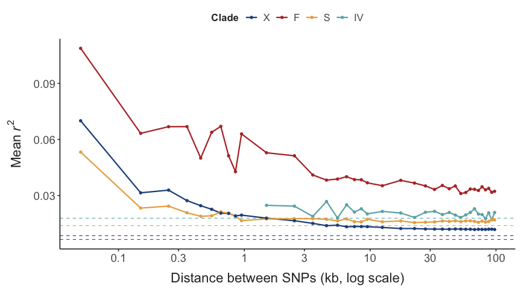

```r
ld_files <- Sys.glob(cx("results", "07_ld", "*.ld_decay.tsv"))
if (length(ld_files) == 0) {
  cat("LD decay is not in this export yet.")
} else {
  ld <- map_dfr(ld_files, ~ read_tsv(.x, col_types = cols(clade = "c"))) %>%   # "F" would otherwise be read as FALSE
    filter(n_pairs >= 50) %>%                 # drop sparse edge bins
    mutate(width = case_when(bin_start_bp < 1000 ~ 100, bin_start_bp < 10000 ~ 1000, TRUE ~ 5000),
           mid_kb = (bin_start_bp + width / 2) / 1000,
           clade = factor(clade, levels = tonsa_clades))
  n_clade <- seq_data %>% filter(clade %in% tonsa_clades, !library_failed) %>%
    count(clade) %>% mutate(clade = factor(clade, levels = tonsa_clades), r2_null = 1 / n)
  write_csv(ld, here("Output", "Output_data", "ld_decay.csv"))
  ggplot(ld, aes(x = mid_kb, y = mean_r2_ExpG, colour = clade)) +
    geom_hline(data = n_clade, aes(yintercept = r2_null, colour = clade), linetype = "dashed", linewidth = 0.4) +
    geom_line(linewidth = 0.8) +
    geom_point(size = 1.2) +
    scale_x_log10(breaks = c(0.1, 0.3, 1, 3, 10, 30, 100), labels = c("0.1", "0.3", "1", "3", "10", "30", "100")) +
    scale_colour_manual(values = clade_cols[tonsa_clades]) +
    labs(x = "Distance between SNPs (kb, log scale)", y = expression(Mean~italic(r)^2), colour = "Clade") +
    theme_matt(base_size = 14)
}
```

### Relatedness and sample quality

Relatedness was estimated with ngsRelate for every pair of individuals within each population. KING-robust kinship does not depend on allele frequencies, so it is less affected than *r*<sub>ab</sub> by the small samples per population: unrelated pairs fall near or below 0, second-degree relatives near 0.125 and first-degree relatives near 0.25. In panel B, related pairs move towards high R1 and high KING; pairs above 0.1 are labelled.

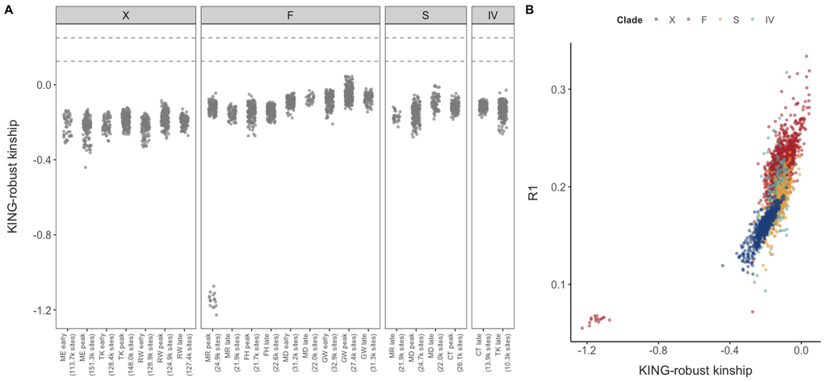

```r
rel_file <- cx("results", "06_relatedness", "relatedness.tsv")
if (!file.exists(rel_file)) {
  cat("Relatedness is not in this export yet.")
} else {
  rel <- read_tsv(rel_file, show_col_types = FALSE) %>%
    select(population, ida, idb, nSites, rab, KING, R0, R1) %>%
    separate(population, c("clade", "site", "season"), sep = "__", remove = FALSE) %>%
    filter(clade %in% tonsa_clades) %>%
    mutate(clade = factor(clade, levels = tonsa_clades),
           site = factor(site, levels = site_order),
           season = factor(season, levels = season_order),
           flag = KING > 0.1,
           pair = paste(ida, idb, sep = " × "))
  rel <- rel %>% mutate(collection = factor(paste(site, season),
                                            levels = unique(paste(site, season)[order(site, season)])))
  write_csv(rel, here("Output", "Output_data", "relatedness_pairs.csv"))
  # x labels carry the median number of sites per pair (precision of the estimates)
  site_n <- rel %>% group_by(collection) %>%
    summarise(lab = sprintf("%s\n(%.1fk sites)", first(collection), median(nSites) / 1000), .groups = "drop")
  rel <- rel %>% mutate(collection = factor(collection, levels = site_n$collection, labels = site_n$lab))

  p_king <- ggplot(rel, aes(x = collection, y = KING)) +
    facet_grid(~ clade, scales = "free_x", space = "free_x") +
    geom_hline(yintercept = c(0.125, 0.25), linetype = "dashed", colour = "grey60") +
    geom_jitter(aes(colour = flag), width = 0.2, height = 0, size = 1, alpha = 0.6) +
    scale_colour_manual(values = c(`FALSE` = "grey55", `TRUE` = "#B73534"), guide = "none") +
    labs(x = NULL, y = "KING-robust kinship") +
    theme_matt_facets(base_size = 12) +
    theme(axis.text.x = element_text(angle = 90, hjust = 1, vjust = 0.5, size = 8))

  p_r1 <- ggplot(rel, aes(x = KING, y = R1)) +
    geom_point(aes(colour = clade), size = 1, alpha = 0.5) +
    geom_point(data = filter(rel, flag), shape = 21, size = 3, colour = "black") +
    geom_text(data = filter(rel, flag), aes(label = pair), hjust = 1.05, vjust = -0.6, size = 3) +
    scale_colour_manual(values = clade_cols[tonsa_clades]) +
    labs(x = "KING-robust kinship", y = "R1", colour = "Clade") +
    theme_matt(base_size = 12)

  ggarrange(p_king, p_r1, nrow = 1, widths = c(1.7, 1), labels = "AUTO")
}
```

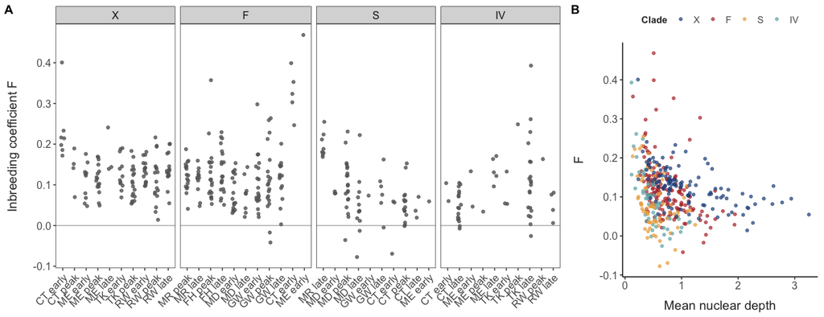

```r
inb_files <- Sys.glob(cx("results", "06_relatedness", "inbreeding", "*.inbreed_samples.tsv"))
if (length(inb_files) == 0) {
  cat("Per-individual inbreeding (heterozygosity check) is not in this export yet.")
} else {
  inb <- map_dfr(inb_files, ~ read_tsv(.x, show_col_types = FALSE)) %>%
    inner_join(select(seq_data, sample_id, clade, site_code, season, mean_depth_nuclear), by = "sample_id") %>%
    filter(clade %in% tonsa_clades) %>%
    mutate(clade = factor(clade, levels = tonsa_clades),
           ord = match(as.character(site_code), site_order) * 10 + match(as.character(season), season_order),
           collection = fct_reorder(paste(site_code, season), ord)) %>%
    group_by(clade) %>%
    # flag only excess heterozygosity (low F); high F mostly reflects low depth (panel B)
    mutate(z = (F - median(F)) / mad(F), flag = z < -4) %>%   # robust z within clade
    ungroup()
  write_csv(inb, here("Output", "Output_data", "inbreeding_individuals.csv"))
  p_f <- ggplot(inb, aes(x = collection, y = F)) +
    facet_grid(~ clade, scales = "free_x", space = "free_x") +
    geom_hline(yintercept = 0, colour = "grey70") +
    geom_jitter(aes(colour = flag), width = 0.15, height = 0, size = 1.4, alpha = 0.8) +
    geom_text(data = filter(inb, flag), aes(label = sample_id), size = 2.6, hjust = -0.1) +
    scale_colour_manual(values = c(`FALSE` = "grey40", `TRUE` = "#B73534"), guide = "none") +
    labs(x = NULL, y = "Inbreeding coefficient F") +
    theme_matt_facets(base_size = 12) +
    theme(axis.text.x = element_text(angle = 45, hjust = 1))
  p_fd <- ggplot(inb, aes(x = mean_depth_nuclear, y = F, colour = clade)) +
    geom_point(size = 1.3, alpha = 0.7) +
    scale_colour_manual(values = clade_cols[tonsa_clades]) +
    labs(x = "Mean nuclear depth", y = "F", colour = "Clade") +
    theme_matt(base_size = 12)
  ggarrange(p_f, p_fd, nrow = 1, widths = c(2.2, 1), labels = "AUTO")
}
```

Per-individual inbreeding coefficients (PCAngsd, allowing for structure within each clade) flag libraries that are more heterozygous than expected (strongly negative F), the signature of DNA from two individuals in one library. Individuals more than 4 robust SDs below their clade’s median are labelled. High F mostly reflects low sequencing depth (panel B: F falls with depth), so only unusually low values are informative. MR_peak_2_04 and MR_peak_2_05 (F = −0.18 and −0.22) were excluded on this basis and no longer appear; no other individual stands out.